# Intro til R

# Intro til R

(Keynote) Hei, og velkommen! Og takk for invitasjonen.

Speaker notes i Keynote.

Keynote ferdig.

```r
library(dplyr)
library(tibble)
library(tidyverse)
library(haven)
library(readxl)
library(readr)
library(psych)
library(broom)
library(ggplot2)
library(ggstatsplot)
library(knitr)
library(broom)
```

# Intro

## Orientere seg i RStudio

Her er RStudio. Du kan helt fint kjøre R uten RStudio, men jeg har aldri vært borti noen som gjør det. Det er bare å åpne R, ikke RStudio, og prøve, så skjønner dere hvorfor. Da har du kun ett enkelt vindu med command-line.

I RStudio har du det samme vinduet, kalt Console. Det er der koden faktisk kjøres. Men i RStudio har du flere andre vinduer rundt, som bygger opp under og gjør Console-vinduet lettere å bruke. Vi skal ta en kjapp titt før vi begynner å taste.

Dere kan selv velge hvilke vinduer dere vil ha hvor, venstre/høyre og oppe/nede. Det dere ser her er slik jeg foretrekker det. Hvordan fungerer fargene? Ser dere skikkelig? Skal jeg bytte til noe lysere, med svart tekst? Selv synes jeg dette er mest behagelig.

Her oppe til høyre har jeg Console. Det er her jeg faktisk kjører koden min. Alt jeg taster inn her, etterfulgt av Enter, blir kjørt som kode.

Det er stort sett veldig upraktisk å kjøre all kode på den måten, live. Du blir veldig sårbar for skrivefeil, og det er vanskelig å holde oversikt over hvor du egentlig er. Derfor kan du heller skrive koden i forskjellige script-filer. Disse har jeg her, oppe til venstre. Da kan du flikke og flikke på koden, sette inn en linje innimellom her eller der, teste ulike ting, og så enten copy/paste enkeltlinjer eller source større deler til console når du vil kjøre den.

Nede til høyre her har jeg forskjellige ting: En fil-manager, samme prinsippet til Finder på mac eller Explorer i Windows. En fane for plot eller all grafikk jeg produserer med koden min. En oversikt over pakker jeg har installert og lastet. En fane for hjelp-dokumentasjon. Denne bruker jeg ganske mye.

Her nede til venstre har jeg mitt Environment. Hvis jeg forklarer det nå gir det ikke mening. Jeg skal forklare den senere, når det gir mening.

I tillegg har jeg en oversikt over History, alle linjer med kode jeg har kjørt. Noen ganger, hvis du vil kjøre en linje om igjen som du kjørte nylig, så kan du bla deg bakover i History og dobbelklikke på den linja, så slipper du å taste den på nytt.

## R som kalkulator

Ok, vi skal opprette en scriptfil og jobbe med den snart. Men nå må vi få tasta litt, så vi får litt grunnleggende syntax inn i fingrene.

På sitt mest grunnleggende oppfører R seg som en kalkulator. Formuler et matematisk uttrykk i console, og du får et svar på neste linje.

```r
1 + 1
```

```
## [1] 2
```

```r
34 / 3
```

```
## [1] 11.33333
```

```r
45 * (13 - 54)
```

```
## [1] -1845
```

Legg merke til at før hvert svar står det et ettall, i firkantklammer. Med disse eksemplene får vi ett element til svar hver gang. Elementet “2”, f.eks. Ettallet viser at 2 er det første elementet i svaret vårt. Hvis vi hadde fått en lang remse over flere linjer i svar, så står det et slikt tall i firkantklemmer for hver linje, som angir hvilket element det første på den linja er.

## Assigne objekter

Vi kan gi innhold til objekter, som vi assigner. Et slik objekt har et navn og navnet kan være enten bare en bokstav eller et lengre ord.

For eksempel kan jeg definere et objekt jeg kaller x, og tildele eller assigne det den numeriske verdien 1.

I R brukes en pil mot venstre som assignment operator: `<-` Du kan tenke på pila som at den tar det til høyre for seg, og putter det inn i det til venstre for seg.

```r
x <- 1
x
```

```
## [1] 1
```

```r
y <- 2
y
```

```
## [1] 2
```

```r
x + y
```

```
## [1] 3
```

```r
z <- x + y
z
```

```
## [1] 3
```

```r
z <- x / y
z
```

```
## [1] 0.5
```

```r
z <- y^y
z
```

```
## [1] 4
```

Dette er et bedre tidspunkt å forklare Environment på. Environmentet ditt utgjøres av den samlingen av objekter som til enhver tid eksisterer i minnet. Altså objekter du har assignet. Akkurat nå inneholder mitt environment tre objekter: x, y og z. Hvis du assigner noe til et objektnavn du allerede har definert, så overskrives alt det gamle innholdet.

Du kan også fjerne objekter fra Environment. Det tar vi etterpå.

## Ulike datatyper, vektorer og subsetting

Funksjonen `c()` “concatenate” brukes til å koble sammen enkeltelementer til vektorer, i ett objekt. Vektor er R-navnet på en serie av verdier. Vi kunne kalt det en variabel, antar jeg. Når vi først har koblet sammen verdiene til en vektor kan du jobbe videre med vektoren som ett enkeltobjekt. Alle regneoperasjoner du gjør med en vektor utføres med hvert enkelt ledd i vektoren separat. Du kan også benytte `c()` til å hekte vektorer på hverandre, til en lengre vektor.

```r
# I console:
x <- c(5, 2, 3, 5, 2, 4, 4, 2)
x
```

```
## [1] 5 2 3 5 2 4 4 2
```

```r
length(x) #funksjonen length tar en vektor som argument, og returnerer lengden på vektoren.
```

```
## [1] 8
```

```r
class(x) #Funksjonen class tar en vektor som argument, og returnerer typen vektor. ALtså om den er numerisk, logisk eller består av tekst. Denne er numerisk, og vi kan se på et par alternativer snart.
```

```
## [1] "numeric"
```

```r
x + 10
```

```
## [1] 15 12 13 15 12 14 14 12
```

```r
x * 10
```

```
## [1] 50 20 30 50 20 40 40 20
```

```r
x + 1000 #Dere ser her at en operasjon som gjøres med en vektor gjøres med alle verdiene i vektoren separat, og de separate svarene returneres.
```

```
## [1] 1005 1002 1003 1005 1002 1004 1004 1002
```

```r
y <- rep(c(10, 200), times = 4) # rep() er en funksjon som tar to argumenter, adskilt med komma. Det første argumentet er noe som skal repeteres. Det andre argumentet, times, er hvor mange ganger det skal repeteres.
y
```

```
## [1]  10 200  10 200  10 200  10 200
```

```r
# Hvis vi utfører en operasjon med to vektorer av lik lengde utføres operasjonen med hhv første ledd i begge vektorene, andre ledd i begge vektorene etc. etc. Legg merke til at x og y er like lange.

length(x)
```

```
## [1] 8
```

```r
length(y)
```

```
## [1] 8
```

```r
length(x) == length(y) #I R brukes "dobbelt-er-lik-tegn" til å angi den logiske operatoren "er lik", i betydningen at noe sammenlignes. Dette er for å unngå misforståelser, for erlik-tegnet kan ha en annen betydning også, at noe tildeles en verdi, ikke ulikt venstrepila, som brukes i noen tilfeller. Poenget er uansett at hvis du vil sammenligne verdier, og be R fortelle deg om det ene er lik det andre, så må du bruke doble erliktegn.
```

```
## [1] TRUE
```

```r
z <- x + y
z
```

```
## [1]  15 202  13 205  12 204  14 202
```

```r
# Eller, x og y ligger fremdeles slik de lå, uendret. Så jeg kan bruke de på nytt til å definere z på en annen måte.

z <- c(x, y)
z
```

```
##  [1]   5   2   3   5   2   4   4   2  10 200  10 200  10 200  10 200
```

```r
# Når man definerer et objekt, så kan man henvise til objektet slik det er allerede når du definerer hvordan det skal bli:

z <- z + 1
z
```

```
##  [1]   6   3   4   6   3   5   5   3  11 201  11 201  11 201  11 201
```

```r
z <- 2*z
z
```

```
##  [1]  12   6   8  12   6  10  10   6  22 402  22 402  22 402  22 402
```

Et objekt, enten det er en vektor eller én verdi, trenger ikke være et tall. Den kan også være logisk, eller tekst. Først tekst:

```r
# w <- c(blue, green, red, yellow)

# Dette blir feil, fordi når vi skriver navn på denne måten så tror R at "blue" og "green" etc. er objekter, som vi refererer til. Vi må bruke hermetegn på ting som skal lagres som tekststring:

#Hente opp den gamle kommandoen, dobbelklikke på tall og legge til anførselstegn.

w <- c("blue", "green", "red", "yellow")
w
```

```
## [1] "blue"   "green"  "red"    "yellow"
```

```r
length(w)
```

```
## [1] 4
```

```r
class(w)
```

```
## [1] "character"
```

Vi bruker firkantklammer bak objektet til subsetting, altså til å gjøre utdrag eller velge elementer fra en vektor.

```r
# I console:

# Første element i z
z[1]
```

```
## [1] 12
```

```r
# Andre element i z
z[2]
```

```
## [1] 6
```

```r
# Første og tredje element i z
# z[1, 3]

# Kan noen gjette hvorfor dette ble feil?
# Et komma inni firkantklammene angir dimensjonene i en tabell. Rader før kommaet, og kolonner etter. Men nå har vi ikke en tabell, bare en vektor. Da blir det feil. Skal vi hente ut første og tredje element må vi gjøre det på denne måten:
z[c(1, 3)]
```

```
## [1] 12  8
```

```r
# Første til tredje element i z
z[1:3]
```

```
## [1] 12  6  8
```

```r
# Men når vi vil ha første til tredje OG sjette, så må vi bruke c() igjen.
z[c(1:3,6)]
```

```
## [1] 12  6  8 10
```

```r
# Minus kan brukes til å angi "ikke". Altså, alle elementer untatt det andre:
z[-2]
```

```
##  [1]  12   8  12   6  10  10   6  22 402  22 402  22 402  22 402
```

```r
# På denne måten kan du subsette etter elementers plassering i vektoren. Man du kan også subsette etter elementets verdi.

z[z < 10]
```

```
## [1] 6 8 6 6
```

```r
z[z > 20]
```

```
## [1]  22 402  22 402  22 402  22 402
```

```r
#I R brukes "dobbelt-er-lik-tegn" til å angi den logiske operatoren "er lik".
z[z == 22]
```

```
## [1] 22 22 22 22
```

```r
# Merk at nå ber jeg om å få returnert de elementene i z som er lik 22. Da får jeg tilbake fire tilfeller av 22, men ingen info om hvor i z de sto. Det er ærlig talt middels nyttig. Istedet kan jeg si til R at z = 22, og jeg får tilbake de tilfellene der dette er sant og de tilfellene der det ikke er sant:

z == 22
```

```
##  [1] FALSE FALSE FALSE FALSE FALSE FALSE FALSE FALSE  TRUE FALSE  TRUE FALSE
## [13]  TRUE FALSE  TRUE FALSE
```

```r
# Jeg kan også assigne dette resultatet til et eget objekt. Da får jeg en ny vektor, q, som ikke er numerisk men logisk.

q <- z == 22
q
```

```
##  [1] FALSE FALSE FALSE FALSE FALSE FALSE FALSE FALSE  TRUE FALSE  TRUE FALSE
## [13]  TRUE FALSE  TRUE FALSE
```

```r
length(q)
```

```
## [1] 16
```

```r
class(q)
```

```
## [1] "logical"
```

```r
# Eller, hvis jeg lurte på hvilke elementer i z som var 22, kan jeg bruke funksjonen which():

which(z == 22)
```

```
## [1]  9 11 13 15
```

```r
which(q)
```

```
## [1]  9 11 13 15
```

```r
# Det funksjonen which() gjør er at den tar et logisk utsagn som argument, og returnerer plasseringen på de tilfellene der det er sant. z == 22 er et slikt utsagn, så du kan fore which() med det. Men q er også et slikt utsagn, så det funker også.

# Dette fungerer med tekstvektorer også:

w <- rep(w, times = 50)
w
```

```
##   [1] "blue"   "green"  "red"    "yellow" "blue"   "green"  "red"    "yellow"
##   [9] "blue"   "green"  "red"    "yellow" "blue"   "green"  "red"    "yellow"
##  [17] "blue"   "green"  "red"    "yellow" "blue"   "green"  "red"    "yellow"
##  [25] "blue"   "green"  "red"    "yellow" "blue"   "green"  "red"    "yellow"
##  [33] "blue"   "green"  "red"    "yellow" "blue"   "green"  "red"    "yellow"
##  [41] "blue"   "green"  "red"    "yellow" "blue"   "green"  "red"    "yellow"
##  [49] "blue"   "green"  "red"    "yellow" "blue"   "green"  "red"    "yellow"
##  [57] "blue"   "green"  "red"    "yellow" "blue"   "green"  "red"    "yellow"
##  [65] "blue"   "green"  "red"    "yellow" "blue"   "green"  "red"    "yellow"
##  [73] "blue"   "green"  "red"    "yellow" "blue"   "green"  "red"    "yellow"
##  [81] "blue"   "green"  "red"    "yellow" "blue"   "green"  "red"    "yellow"
##  [89] "blue"   "green"  "red"    "yellow" "blue"   "green"  "red"    "yellow"
##  [97] "blue"   "green"  "red"    "yellow" "blue"   "green"  "red"    "yellow"
## [105] "blue"   "green"  "red"    "yellow" "blue"   "green"  "red"    "yellow"
## [113] "blue"   "green"  "red"    "yellow" "blue"   "green"  "red"    "yellow"
## [121] "blue"   "green"  "red"    "yellow" "blue"   "green"  "red"    "yellow"
## [129] "blue"   "green"  "red"    "yellow" "blue"   "green"  "red"    "yellow"
## [137] "blue"   "green"  "red"    "yellow" "blue"   "green"  "red"    "yellow"
## [145] "blue"   "green"  "red"    "yellow" "blue"   "green"  "red"    "yellow"
## [153] "blue"   "green"  "red"    "yellow" "blue"   "green"  "red"    "yellow"
## [161] "blue"   "green"  "red"    "yellow" "blue"   "green"  "red"    "yellow"
## [169] "blue"   "green"  "red"    "yellow" "blue"   "green"  "red"    "yellow"
## [177] "blue"   "green"  "red"    "yellow" "blue"   "green"  "red"    "yellow"
## [185] "blue"   "green"  "red"    "yellow" "blue"   "green"  "red"    "yellow"
## [193] "blue"   "green"  "red"    "yellow" "blue"   "green"  "red"    "yellow"
```

```r
which(w == "green")
```

```
##  [1]   2   6  10  14  18  22  26  30  34  38  42  46  50  54  58  62  66  70  74
## [20]  78  82  86  90  94  98 102 106 110 114 118 122 126 130 134 138 142 146 150
## [39] 154 158 162 166 170 174 178 182 186 190 194 198
```

```r
which(w == "blue")
```

```
##  [1]   1   5   9  13  17  21  25  29  33  37  41  45  49  53  57  61  65  69  73
## [20]  77  81  85  89  93  97 101 105 109 113 117 121 125 129 133 137 141 145 149
## [39] 153 157 161 165 169 173 177 181 185 189 193 197
```

```r
# I tillegg kan jeg bruke anledningen til å vise frem funksjonen sort(). Den tar en vektor som argument, og returnerer den ferdig sortert.

sort(w) # I tilfellet tekstvektorer blir det alfabetisk
```

```
##   [1] "blue"   "blue"   "blue"   "blue"   "blue"   "blue"   "blue"   "blue"
##   [9] "blue"   "blue"   "blue"   "blue"   "blue"   "blue"   "blue"   "blue"
##  [17] "blue"   "blue"   "blue"   "blue"   "blue"   "blue"   "blue"   "blue"
##  [25] "blue"   "blue"   "blue"   "blue"   "blue"   "blue"   "blue"   "blue"
##  [33] "blue"   "blue"   "blue"   "blue"   "blue"   "blue"   "blue"   "blue"
##  [41] "blue"   "blue"   "blue"   "blue"   "blue"   "blue"   "blue"   "blue"
##  [49] "blue"   "blue"   "green"  "green"  "green"  "green"  "green"  "green"
##  [57] "green"  "green"  "green"  "green"  "green"  "green"  "green"  "green"
##  [65] "green"  "green"  "green"  "green"  "green"  "green"  "green"  "green"
##  [73] "green"  "green"  "green"  "green"  "green"  "green"  "green"  "green"
##  [81] "green"  "green"  "green"  "green"  "green"  "green"  "green"  "green"
##  [89] "green"  "green"  "green"  "green"  "green"  "green"  "green"  "green"
##  [97] "green"  "green"  "green"  "green"  "red"    "red"    "red"    "red"
## [105] "red"    "red"    "red"    "red"    "red"    "red"    "red"    "red"
## [113] "red"    "red"    "red"    "red"    "red"    "red"    "red"    "red"
## [121] "red"    "red"    "red"    "red"    "red"    "red"    "red"    "red"
## [129] "red"    "red"    "red"    "red"    "red"    "red"    "red"    "red"
## [137] "red"    "red"    "red"    "red"    "red"    "red"    "red"    "red"
## [145] "red"    "red"    "red"    "red"    "red"    "red"    "yellow" "yellow"
## [153] "yellow" "yellow" "yellow" "yellow" "yellow" "yellow" "yellow" "yellow"
## [161] "yellow" "yellow" "yellow" "yellow" "yellow" "yellow" "yellow" "yellow"
## [169] "yellow" "yellow" "yellow" "yellow" "yellow" "yellow" "yellow" "yellow"
## [177] "yellow" "yellow" "yellow" "yellow" "yellow" "yellow" "yellow" "yellow"
## [185] "yellow" "yellow" "yellow" "yellow" "yellow" "yellow" "yellow" "yellow"
## [193] "yellow" "yellow" "yellow" "yellow" "yellow" "yellow" "yellow" "yellow"
```

```r
sort(w, decreasing = TRUE) #Dersom argumentet decreasing ikke spesifiseres så settes det by default til FALSE. Men det kan spesifiseres til TRUE.
```

```
##   [1] "yellow" "yellow" "yellow" "yellow" "yellow" "yellow" "yellow" "yellow"
##   [9] "yellow" "yellow" "yellow" "yellow" "yellow" "yellow" "yellow" "yellow"
##  [17] "yellow" "yellow" "yellow" "yellow" "yellow" "yellow" "yellow" "yellow"
##  [25] "yellow" "yellow" "yellow" "yellow" "yellow" "yellow" "yellow" "yellow"
##  [33] "yellow" "yellow" "yellow" "yellow" "yellow" "yellow" "yellow" "yellow"
##  [41] "yellow" "yellow" "yellow" "yellow" "yellow" "yellow" "yellow" "yellow"
##  [49] "yellow" "yellow" "red"    "red"    "red"    "red"    "red"    "red"
##  [57] "red"    "red"    "red"    "red"    "red"    "red"    "red"    "red"
##  [65] "red"    "red"    "red"    "red"    "red"    "red"    "red"    "red"
##  [73] "red"    "red"    "red"    "red"    "red"    "red"    "red"    "red"
##  [81] "red"    "red"    "red"    "red"    "red"    "red"    "red"    "red"
##  [89] "red"    "red"    "red"    "red"    "red"    "red"    "red"    "red"
##  [97] "red"    "red"    "red"    "red"    "green"  "green"  "green"  "green"
## [105] "green"  "green"  "green"  "green"  "green"  "green"  "green"  "green"
## [113] "green"  "green"  "green"  "green"  "green"  "green"  "green"  "green"
## [121] "green"  "green"  "green"  "green"  "green"  "green"  "green"  "green"
## [129] "green"  "green"  "green"  "green"  "green"  "green"  "green"  "green"
## [137] "green"  "green"  "green"  "green"  "green"  "green"  "green"  "green"
## [145] "green"  "green"  "green"  "green"  "green"  "green"  "blue"   "blue"
## [153] "blue"   "blue"   "blue"   "blue"   "blue"   "blue"   "blue"   "blue"
## [161] "blue"   "blue"   "blue"   "blue"   "blue"   "blue"   "blue"   "blue"
## [169] "blue"   "blue"   "blue"   "blue"   "blue"   "blue"   "blue"   "blue"
## [177] "blue"   "blue"   "blue"   "blue"   "blue"   "blue"   "blue"   "blue"
## [185] "blue"   "blue"   "blue"   "blue"   "blue"   "blue"   "blue"   "blue"
## [193] "blue"   "blue"   "blue"   "blue"   "blue"   "blue"   "blue"   "blue"
```

```r
# Merk at jeg ikke har endret på w nå. Fargene ligger fremdeles i den opprinnelige rekkefølgen. Jeg har bare bedt om å få dem fremvist sortert. Derimot, hvis jeg gjør slik:

w <- sort(w)

# ...så blir den sånn.

w
```

```
##   [1] "blue"   "blue"   "blue"   "blue"   "blue"   "blue"   "blue"   "blue"
##   [9] "blue"   "blue"   "blue"   "blue"   "blue"   "blue"   "blue"   "blue"
##  [17] "blue"   "blue"   "blue"   "blue"   "blue"   "blue"   "blue"   "blue"
##  [25] "blue"   "blue"   "blue"   "blue"   "blue"   "blue"   "blue"   "blue"
##  [33] "blue"   "blue"   "blue"   "blue"   "blue"   "blue"   "blue"   "blue"
##  [41] "blue"   "blue"   "blue"   "blue"   "blue"   "blue"   "blue"   "blue"
##  [49] "blue"   "blue"   "green"  "green"  "green"  "green"  "green"  "green"
##  [57] "green"  "green"  "green"  "green"  "green"  "green"  "green"  "green"
##  [65] "green"  "green"  "green"  "green"  "green"  "green"  "green"  "green"
##  [73] "green"  "green"  "green"  "green"  "green"  "green"  "green"  "green"
##  [81] "green"  "green"  "green"  "green"  "green"  "green"  "green"  "green"
##  [89] "green"  "green"  "green"  "green"  "green"  "green"  "green"  "green"
##  [97] "green"  "green"  "green"  "green"  "red"    "red"    "red"    "red"
## [105] "red"    "red"    "red"    "red"    "red"    "red"    "red"    "red"
## [113] "red"    "red"    "red"    "red"    "red"    "red"    "red"    "red"
## [121] "red"    "red"    "red"    "red"    "red"    "red"    "red"    "red"
## [129] "red"    "red"    "red"    "red"    "red"    "red"    "red"    "red"
## [137] "red"    "red"    "red"    "red"    "red"    "red"    "red"    "red"
## [145] "red"    "red"    "red"    "red"    "red"    "red"    "yellow" "yellow"
## [153] "yellow" "yellow" "yellow" "yellow" "yellow" "yellow" "yellow" "yellow"
## [161] "yellow" "yellow" "yellow" "yellow" "yellow" "yellow" "yellow" "yellow"
## [169] "yellow" "yellow" "yellow" "yellow" "yellow" "yellow" "yellow" "yellow"
## [177] "yellow" "yellow" "yellow" "yellow" "yellow" "yellow" "yellow" "yellow"
## [185] "yellow" "yellow" "yellow" "yellow" "yellow" "yellow" "yellow" "yellow"
## [193] "yellow" "yellow" "yellow" "yellow" "yellow" "yellow" "yellow" "yellow"
```

```r
# Samme med tall:

sort(z)
```

```
##  [1]   6   6   6   8  10  10  12  12  22  22  22  22 402 402 402 402
```

## Tabelldata

Vektorer av samme lengde kan samles i tabeller, og utgjøre datasett. Det finnes ulike lagringsformater for slike tabeller, f.eks. matrix eller data.table. Jeg kommer til å fokusere på en type som heter `tibble()`, pga kompatibilitet med en del funksjoner vi bruker senere.

Alle funksjoner i R har et navn etterfulgt av en parantes. Dere har brukt et par funksjoner allerede, nemlig `sort()`, `which()`, `rep()`, `length()` og `class()`.

`tibble()` er også en funksjon. Det tibble gjør er at den lagrer data for oss i et spesielt tabellformat kalt en tibble. Inni parantesen til en funksjon kommer argumentene man forer funksjonen med. F.eks. når vi brukte funksjonen `rep()` så anga vi hvor mange ganger vi ønsket å repetere med argumentet times. Og i `sort()` fantes et argument som het decreasing og som kunne angis til `TRUE` eller `FALSE`. I tilfellet `tibble()` er argumentene de kolonnene man ønsker skal utgjøre tabellen, angitt på formatet `navn på kolonnen = verdier` inni `c()` eller som et uttrykk. Mellom angivelsen av hver kolonne bruker man komma.

Et enkelt eksempel:

```r
data <- tibble(time = c(45, 40, 42, 47, 43), speed = c(34, 36, 32, 34, 23))

# Nå har jeg objektet "data" i mitt Environment. Vi kan titte på det:

data
```

```
## # A tibble: 5 × 2
##    time speed
##   <dbl> <dbl>
## 1    45    34
## 2    40    36
## 3    42    32
## 4    47    34
## 5    43    23
```

Dette er en vrien måte å gjøre det på. Hvis vi har vektorer liggende i environment fra før kan vi bruke de, ved å oppgi navnet på dem.

```r
x <- c(45, 40, 42, 47, 43)
y <- c(34, 36, 32, 34, 23)

data2 <- tibble(
        tid = x,
        fart = y,

# Man kan også definere kolonner som matematiske uttrykk, og man kan referere til tidligere kolonner når man oppretter nye

        distanse = tid * fart
)
```

Vi kan subsette tabelldata på samme måte som med vektorer, med firkantklammer. Husk at dere da må ha et komma inni firkantklammene, og at rader kommer først og kolonner etter

```r
# Første rad:
data2[1,]
```

```
## # A tibble: 1 × 3
##     tid  fart distanse
##   <dbl> <dbl>    <dbl>
## 1    45    34     1530
```

```r
# Første kolonne:
data2[,1]
```

```
## # A tibble: 5 × 1
##     tid
##   <dbl>
## 1    45
## 2    40
## 3    42
## 4    47
## 5    43
```

```r
# Første og tredje kolonne:
data2[,c(1,3)]
```

```
## # A tibble: 5 × 2
##     tid distanse
##   <dbl>    <dbl>
## 1    45     1530
## 2    40     1440
## 3    42     1344
## 4    47     1598
## 5    43      989
```

```r
# Alle kolonner utenom den første:
data2[,-1]
```

```
## # A tibble: 5 × 2
##    fart distanse
##   <dbl>    <dbl>
## 1    34     1530
## 2    36     1440
## 3    32     1344
## 4    34     1598
## 5    23      989
```

```r
# Når vi jobber med tabelldata kan vi også subsette på en annen måte. Vi kan bruke dollartegn til å hente enkeltkolonner, eller variabler, som en vektor. Da kommer navnet på objektet før dollartegnet og variabelnavnet etter:

data2$tid
```

```
## [1] 45 40 42 47 43
```

```r
data2$distanse
```

```
## [1] 1530 1440 1344 1598  989
```

## Finne hjelp

Nå kommer et bra triks: Hvis dere lurer på hva en funksjon gjør, og hvilke argumenter akkurat den funksjonen kan ta imot og hva som er default, så kan dere skrive navnet på funksjonen med et spørsmåltegn foran

```r
?rep
?which
?sort
```

## Slette alt i Environment og sette Working Directory

Men vi skal videre. Å sitte og taste inn data manuelt med `tibble()` er ikke noe særlig effektivt. Jeg lover at det har vi gjort for siste gang. Fra nå skal vi importere data.

Vi skal ta pause, men først et par ord om filstruktur og working directory. Vi kan, med R-kode, henvise til filer som ligger lagret på maskinen vår, og vi kan selv opprette og lagre filer. Så når vi jobber så tenker alltid R at den befinner seg på et bestemt sted i filstrukturen vår, eller jobber ut fra et bestemt sted. Dette kalles working directory. Vi kan finne ut hva som er vårt nåværende working directory med funksjonen `getwd()`.

```r
getwd()
```

```
## [1] "/Users/hsorlie/Documents/R/Teaching/intro_to_R"
```

Hvis vi hadde lagret en fil med R-kode nå, uten å spesifisere hvor, så hadde den blitt lagret i denne banen. Vi kunne definert et annet sted, men da måtte vi spesifisert det med utgangspunkt i dette stedet.

Vi kan også angi working directory med tilsvarende funksjon `setwd()`. Men det er litt knottete å holde på slik, og istedet så skal vi jobbe med Prosjekter, en funksjon i RStudio som tar seg av dette for oss. Det kan vi opprette etter pausen, men først skal jeg vise hvordan dere sletter ting fra Environment. Det gjør du med kommandoen `rm()`. Så kan du liste opp én eller flere objekter du vil slette.

```r
rm(x)

#Er det flere adskiller du med komma:

rm(q, w)

#Du kan bruke funksjonen ls til å få listet opp alle nåværende objekter i Environment som en tekststring.

ls()
```

```
## [1] "data"  "data2" "y"     "z"
```

```r
# Og rm()-funksjonen har et argument som heter list, som tar en tekststring med navn på objekter som input. Følgelig kan du alltid slette alle objekter i environment samtidig, med kommandoen:

rm(list = ls())
```

*(PAUSE)* 50 min. hit, inkl. keynote.

# Tidyverse

## Prosjekter

Når vi nå fortsetter skal vi først opprette et Prosjekt. Prosjekter er en funksjonalitet i RStudio som gjør at vi slipper å bekymre oss for mye om working directory og slikt. Innenfor ett prosjekt kan du holde deg med så mange filer du bare vil, og lagre og styre på. Men du kan jobbe med flere prosjekter separat, i ulike RStudio-vinduer, samtidig om så. Environment holdes adskilt, og working directory settes til folderen for prosjektet. Jeg enbefaler at dere lager dere en mappe under Dokumenter, som dere f.eks. kaller R. Den mappen blir i så fall det naturlige stedet å lagre prosjektene deres.

*Opprette nytt prosjekt*

Da har vi et tomt Environment, og Working Directory er satt til dette prosjektet, så det slipper vi å tenke på. I dette prosjektet kan vi nå åpne en ny fil. En script-fil.

Da velger dere File, New File, RScript. Det er lettere å jobbe med en scriptfil enn direkte i console fordi du her kan flikke og flikke på koden, og så trykke på Play når den ser klar ut, så sendes den til console.

## Data transformasjon

Vi skal i hovedsak herfra titte på tidyverse, et sett pakker som fungerer bra sammen for å lese, transformere og behandle data, og plotte. Tidyverse består som sagt av flere pakker, hver med et sett funksjoner. Men de er laget på en slik måte at de har felles syntaks, og felles oppbygning av argumenter.

Vi begynner med å laste et datasett, så vi har noe å jobbe med. Det finner vi i pakken “nycflights13”.

```r
#install.packages("nycflights13")
library(nycflights13)
```

*Keynote*

Her er de viktigste funksjonene vi skal bruke:

`filter()` velger observasjoner/rader, basert på verdi. `select()` velger variabler basert på navn. `mutate()` lar oss lage nye variabler eller endre gamle. `summarise()` koker ned flere verdier til ett tall.

Alle disse funksjonene fungerer på følgende måte: De tar et objekt, som et datasett, som første argument. For alle påfølgende argumenter sier du hva du vil gjøre med datasettet, ved å bruke variabelnavn. Outputen av funksjonen er et nytt datasett.

Og dette fungerer sammen med funksjonen `group_by()`. Den gjør at hver av de andre funksjonene fungerer innad i en hver definerte gruppe av datasettet, og ikke bare på datasettet som helhet. Si f.eks at du bruker summarise() til å lage snittscorer for variabler. Da vil group_by() sørge for at snittet ikke blir for datasettet som helhet, for innad for hver gruppe basert på en annen variabel.

Før vi fortsetter så trenger vi et skikkelig datasett å jobbe med:

```r
flights
```

```
## # A tibble: 336,776 × 19
##     year month   day dep_time sched_dep_time dep_delay arr_time sched_arr_time
##    <int> <int> <int>    <int>          <int>     <dbl>    <int>          <int>
##  1  2013     1     1      517            515         2      830            819
##  2  2013     1     1      533            529         4      850            830
##  3  2013     1     1      542            540         2      923            850
##  4  2013     1     1      544            545        -1     1004           1022
##  5  2013     1     1      554            600        -6      812            837
##  6  2013     1     1      554            558        -4      740            728
##  7  2013     1     1      555            600        -5      913            854
##  8  2013     1     1      557            600        -3      709            723
##  9  2013     1     1      557            600        -3      838            846
## 10  2013     1     1      558            600        -2      753            745
## # … with 336,766 more rows, and 11 more variables: arr_delay <dbl>,
## #   carrier <chr>, flight <int>, tailnum <chr>, origin <chr>, dest <chr>,
## #   air_time <dbl>, distance <dbl>, hour <dbl>, minute <dbl>, time_hour <dttm>
```

Vi kan få mer info om det med

```r
?flights #Skumme over alla variabelnavn før vi fortsetter
```

Det inneholder faktiske data om hvert eneste fly som forlot New York i 2013, i alt 336.776 observasjoner av 19 variabler.

Vi kan begynne med `filter()`. La oss si at vi er interessert kun i flyene som forlot NY på kvinnedagen:

```r
filter(flights, month == 3, day == 8)
```

```
## # A tibble: 979 × 19
##     year month   day dep_time sched_dep_time dep_delay arr_time sched_arr_time
##    <int> <int> <int>    <int>          <int>     <dbl>    <int>          <int>
##  1  2013     3     8        1           2355         6      431            440
##  2  2013     3     8        5           2020       225      226           2318
##  3  2013     3     8        8           2145       143      240             34
##  4  2013     3     8        9           2155       134      238             48
##  5  2013     3     8       11           2230       101      437            312
##  6  2013     3     8       12           2245        87      127           2356
##  7  2013     3     8       13           2140       153      144           2305
##  8  2013     3     8       17           1918       299      237           2216
##  9  2013     3     8       22           2359        23      447            438
## 10  2013     3     8       22           2150       152      258             42
## # … with 969 more rows, and 11 more variables: arr_delay <dbl>, carrier <chr>,
## #   flight <int>, tailnum <chr>, origin <chr>, dest <chr>, air_time <dbl>,
## #   distance <dbl>, hour <dbl>, minute <dbl>, time_hour <dttm>
```

```r
#Og nå får vi det bare listet opp. Men hvis vi vil ta vare på det så kan vi selvsagt assigne det til et nytt objekt med en gang, slik:

fly8mars <- filter(flights, month == 3, day == 8)

#Vi kan bruke logiske operators for å angi flere tilstander som må oppfylles. Her finner vi f.eks. alle avgangene i november og desember ved å be om november ELLER desember.

filter(flights, month == 11 | month == 12)
```

```
## # A tibble: 55,403 × 19
##     year month   day dep_time sched_dep_time dep_delay arr_time sched_arr_time
##    <int> <int> <int>    <int>          <int>     <dbl>    <int>          <int>
##  1  2013    11     1        5           2359         6      352            345
##  2  2013    11     1       35           2250       105      123           2356
##  3  2013    11     1      455            500        -5      641            651
##  4  2013    11     1      539            545        -6      856            827
##  5  2013    11     1      542            545        -3      831            855
##  6  2013    11     1      549            600       -11      912            923
##  7  2013    11     1      550            600       -10      705            659
##  8  2013    11     1      554            600        -6      659            701
##  9  2013    11     1      554            600        -6      826            827
## 10  2013    11     1      554            600        -6      749            751
## # … with 55,393 more rows, and 11 more variables: arr_delay <dbl>,
## #   carrier <chr>, flight <int>, tailnum <chr>, origin <chr>, dest <chr>,
## #   air_time <dbl>, distance <dbl>, hour <dbl>, minute <dbl>, time_hour <dttm>
```

```r
#Eller vi kan finne alle avgangene i juni som var mer enn én time forsinket:

filter(flights, month == 6 & dep_delay > 60)
```

```
## # A tibble: 3,494 × 19
##     year month   day dep_time sched_dep_time dep_delay arr_time sched_arr_time
##    <int> <int> <int>    <int>          <int>     <dbl>    <int>          <int>
##  1  2013     6     1      833            700        93     1119           1006
##  2  2013     6     1      844            640       124     1038            843
##  3  2013     6     1     1119           1003        76     1310           1214
##  4  2013     6     1     1402           1300        62     1640           1548
##  5  2013     6     1     1439           1300        99     1741           1555
##  6  2013     6     1     1807           1530       157     2004           1758
##  7  2013     6     1     1809           1250       319     2000           1448
##  8  2013     6     1     1834           1640       114     2036           1845
##  9  2013     6     1     1837           1650       107     2054           1914
## 10  2013     6     1     1918           1700       138     2101           1850
## # … with 3,484 more rows, and 11 more variables: arr_delay <dbl>,
## #   carrier <chr>, flight <int>, tailnum <chr>, origin <chr>, dest <chr>,
## #   air_time <dbl>, distance <dbl>, hour <dbl>, minute <dbl>, time_hour <dttm>
```

Ok, det var `filter()`. Neste er `select()`. Den er ganske basic. Den bare plukker variablene du er interessert i. Men den er ganske praktisk hvis du skal sakse ned et stort datasett til noe mer håndterbart for å gjøre analyser.

```r
select(flights, carrier, flight, distance)
```

```
## # A tibble: 336,776 × 3
##    carrier flight distance
##    <chr>    <int>    <dbl>
##  1 UA        1545     1400
##  2 UA        1714     1416
##  3 AA        1141     1089
##  4 B6         725     1576
##  5 DL         461      762
##  6 UA        1696      719
##  7 B6         507     1065
##  8 EV        5708      229
##  9 B6          79      944
## 10 AA         301      733
## # … with 336,766 more rows
```

```r
#Du kan bruke kolon : for å angi alle variabler mellom to.

select(flights, carrier, flight, year:day)
```

```
## # A tibble: 336,776 × 5
##    carrier flight  year month   day
##    <chr>    <int> <int> <int> <int>
##  1 UA        1545  2013     1     1
##  2 UA        1714  2013     1     1
##  3 AA        1141  2013     1     1
##  4 B6         725  2013     1     1
##  5 DL         461  2013     1     1
##  6 UA        1696  2013     1     1
##  7 B6         507  2013     1     1
##  8 EV        5708  2013     1     1
##  9 B6          79  2013     1     1
## 10 AA         301  2013     1     1
## # … with 336,766 more rows
```

```r
#Du kan også bruke hjelpefunksjonene starts_with(), ends_with() eller contains()

select(flights, contains("delay"), carrier, year:day)
```

```
## # A tibble: 336,776 × 6
##    dep_delay arr_delay carrier  year month   day
##        <dbl>     <dbl> <chr>   <int> <int> <int>
##  1         2        11 UA       2013     1     1
##  2         4        20 UA       2013     1     1
##  3         2        33 AA       2013     1     1
##  4        -1       -18 B6       2013     1     1
##  5        -6       -25 DL       2013     1     1
##  6        -4        12 UA       2013     1     1
##  7        -5        19 B6       2013     1     1
##  8        -3       -14 EV       2013     1     1
##  9        -3        -8 B6       2013     1     1
## 10        -2         8 AA       2013     1     1
## # … with 336,766 more rows
```

Og så `mutate()`. Den er supernyttig. La oss først lage et lite datasett med noen få variabler:

```r
miniflights <- select(flights, year:day, ends_with("delay"), distance, air_time)

#Mutate lager nye variabler og legger dem til bakerst på datasettet.

mutate(miniflights,
  gain = dep_delay - arr_delay,
  speed = distance / air_time * 60
)
```

```
## # A tibble: 336,776 × 9
##     year month   day dep_delay arr_delay distance air_time  gain speed
##    <int> <int> <int>     <dbl>     <dbl>    <dbl>    <dbl> <dbl> <dbl>
##  1  2013     1     1         2        11     1400      227    -9  370.
##  2  2013     1     1         4        20     1416      227   -16  374.
##  3  2013     1     1         2        33     1089      160   -31  408.
##  4  2013     1     1        -1       -18     1576      183    17  517.
##  5  2013     1     1        -6       -25      762      116    19  394.
##  6  2013     1     1        -4        12      719      150   -16  288.
##  7  2013     1     1        -5        19     1065      158   -24  404.
##  8  2013     1     1        -3       -14      229       53    11  259.
##  9  2013     1     1        -3        -8      944      140     5  405.
## 10  2013     1     1        -2         8      733      138   -10  319.
## # … with 336,766 more rows
```

```r
#Vi kan bruke en beslektet funksjon, transmute(), istedenfor, hvis vi kun vil ha de nye variablene, og ikke beholde de gamle.

transmute(miniflights,
  gain = dep_delay - arr_delay,
  speed = distance / air_time * 60
)
```

```
## # A tibble: 336,776 × 2
##     gain speed
##    <dbl> <dbl>
##  1    -9  370.
##  2   -16  374.
##  3   -31  408.
##  4    17  517.
##  5    19  394.
##  6   -16  288.
##  7   -24  404.
##  8    11  259.
##  9     5  405.
## 10   -10  319.
## # … with 336,766 more rows
```

```r
#Og legg også merke til at man kan referere til variabler man nettopp har opprettet:

transmute(miniflights,
  gain = dep_delay - arr_delay,
  speed = distance / air_time * 60,
  hours = air_time / 60,
  gain_per_hour = gain / hours
)
```

```
## # A tibble: 336,776 × 4
##     gain speed hours gain_per_hour
##    <dbl> <dbl> <dbl>         <dbl>
##  1    -9  370. 3.78          -2.38
##  2   -16  374. 3.78          -4.23
##  3   -31  408. 2.67         -11.6
##  4    17  517. 3.05           5.57
##  5    19  394. 1.93           9.83
##  6   -16  288. 2.5           -6.4
##  7   -24  404. 2.63          -9.11
##  8    11  259. 0.883         12.5
##  9     5  405. 2.33           2.14
## 10   -10  319. 2.3           -4.35
## # … with 336,766 more rows
```

Neste er `summarise()`. Den kollapser en variabel ned til én verdi.

```r
summarise(flights, mean_delay = mean(dep_delay))
```

```
## # A tibble: 1 × 1
##   mean_delay
##        <dbl>
## 1         NA
```

Yes! Nå fikk vi `NA`. Så dette er et fint tidspunkt å ta det på. `NA` står for “not available”, og det er slik missing verdier ser ut i R. Tolkningen er altså at der det står `NA` vet ikke R hva det egentlig skulle stått. Og det gjør `NA` svært smittsomt, fordi nesten alle operasjoner som involverer én `NA` også får `NA` til svar. Et eksempel:

```r
x <- c(1, 2, 3, 4, 5)
y <- 10
z <- NA

x + y
```

```
## [1] 11 12 13 14 15
```

```r
x + z
```

```
## [1] NA NA NA NA NA
```

Dette er virkelig noe å ha i bakhodet, f.eks. når man regner summescorer av items, for å få scorer på variabler. For det betyr at hvis du ikke foretar deg noe så blir hele summescorer `NA`, eller missing, for en respondent hvis én av itemene er NA. Hvis det er et måleverktøy der mange items laster på én faktor, så kan det bli ganske stygt. Jeg har vært borti dette med f.eks. NEO, som har 240 items som laster på 30 personlighetsfasetter, som igjen laster på 5 personlighetsfaktorer. Det var et datasett på et par tusen, og det var ikke veldig mye missing, men litt. Og der det var missing var det kanskje slik at en respondent hadde missing på én item av 240, midt inni der et sted. Og hvis én av åtte items i en fasett er missing så blir fasetten missing. Og hvis én av seks fasetter i en faktor er missing, så blir faktoren missing. Noen ganger må det jo bare bli sånn, men man må kanskje i det minste kunne diskutere hvor mange items man kan tåle er missing uten at det går ut over konstruktvaliditeten hvis man tar snittet av de resterende.

Jeg vet ikke hva som er riktig sånn sett, men den tekniske løsninga er enkel. Vi må ofte be R eksplisitt om å ignorere NAer.

Så, tilbake til `summarise()`…

```r
summarise(flights, mean_delay = mean(dep_delay, na.rm = TRUE))
```

```
## # A tibble: 1 × 1
##   mean_delay
##        <dbl>
## 1       12.6
```

Da får vi et svar. Men denne funksjonen er riktignok ikke veldig nyttig med mindre den kombineres med `group_by`, så da tar vi den.

```r
flightsbycarrier <- group_by(flights, carrier)

#Sammenlign disse datasettene et øyeblikk:
flights
```

```
## # A tibble: 336,776 × 19
##     year month   day dep_time sched_dep_time dep_delay arr_time sched_arr_time
##    <int> <int> <int>    <int>          <int>     <dbl>    <int>          <int>
##  1  2013     1     1      517            515         2      830            819
##  2  2013     1     1      533            529         4      850            830
##  3  2013     1     1      542            540         2      923            850
##  4  2013     1     1      544            545        -1     1004           1022
##  5  2013     1     1      554            600        -6      812            837
##  6  2013     1     1      554            558        -4      740            728
##  7  2013     1     1      555            600        -5      913            854
##  8  2013     1     1      557            600        -3      709            723
##  9  2013     1     1      557            600        -3      838            846
## 10  2013     1     1      558            600        -2      753            745
## # … with 336,766 more rows, and 11 more variables: arr_delay <dbl>,
## #   carrier <chr>, flight <int>, tailnum <chr>, origin <chr>, dest <chr>,
## #   air_time <dbl>, distance <dbl>, hour <dbl>, minute <dbl>, time_hour <dttm>
```

```r
flightsbycarrier
```

```
## # A tibble: 336,776 × 19
## # Groups:   carrier [16]
##     year month   day dep_time sched_dep_time dep_delay arr_time sched_arr_time
##    <int> <int> <int>    <int>          <int>     <dbl>    <int>          <int>
##  1  2013     1     1      517            515         2      830            819
##  2  2013     1     1      533            529         4      850            830
##  3  2013     1     1      542            540         2      923            850
##  4  2013     1     1      544            545        -1     1004           1022
##  5  2013     1     1      554            600        -6      812            837
##  6  2013     1     1      554            558        -4      740            728
##  7  2013     1     1      555            600        -5      913            854
##  8  2013     1     1      557            600        -3      709            723
##  9  2013     1     1      557            600        -3      838            846
## 10  2013     1     1      558            600        -2      753            745
## # … with 336,766 more rows, and 11 more variables: arr_delay <dbl>,
## #   carrier <chr>, flight <int>, tailnum <chr>, origin <chr>, dest <chr>,
## #   air_time <dbl>, distance <dbl>, hour <dbl>, minute <dbl>, time_hour <dttm>
```

Ser dere at de ser like ut? Like dimensjoner, samme variabler. Men den ene har angitt “groups”. 16 ulike verdier av carrier. Og alle andre funksjoner vi gjør med dette datasettet, blir gjort for hver gruppe av datasettet. Iallefall alle tidyverse-funksjoner respekterer denne grupperingen.

```r
summarise(flightsbycarrier, mean_delay = mean(dep_delay, na.rm = TRUE))
```

```
## # A tibble: 16 × 2
##    carrier mean_delay
##    <chr>        <dbl>
##  1 9E           16.7
##  2 AA            8.59
##  3 AS            5.80
##  4 B6           13.0
##  5 DL            9.26
##  6 EV           20.0
##  7 F9           20.2
##  8 FL           18.7
##  9 HA            4.90
## 10 MQ           10.6
## 11 OO           12.6
## 12 UA           12.1
## 13 US            3.78
## 14 VX           12.9
## 15 WN           17.7
## 16 YV           19.0
```

## Importere og koble data

Vi kan importere data fra hvilken som helst kilde. Fra Excel, fra CSVer, fra ren tekst, fra SPSS-filer. Hva som helst. I dette tilfellet skal vi importere data fra en SPSS-fil. Den funksjonaliteten ligger ikke i R i utgangspunktet, men den mest brukte pakken som gir oss denne funksjonaliteten heter Haven. I tillegg til SPSS-filer gir haven mulighet til å importere og eksportere data fra Stata og SAS, hvis noen skulle trenge det.

Dere har fått delt noen filer som vi skal bruke. Jeg foreslår at dere legger de under en mappe som heter “data” der dere har prosjektet dere. Slik…

*opprette mappe som heter `data` og legge filene der*

Først skal vi lese inn seleksjonsdata.sav. Til det skal vi bruke funksjonen `read_spss()`. Vi kan jo starte med å sjekke hjelpfila:

```r
?read_spss
```

Ser ganske straightforward ut. Spoiler alert: Det er det.

```r
read_spss("data/seleksjonsdata.sav")
```

```
## # A tibble: 400 × 6
##       ID     Gender    AE Skolepoeng BS_karakter Tj_snitt
##    <dbl>  <dbl+lbl> <dbl>      <dbl>       <dbl>    <dbl>
##  1     1 2 [Mann]       5       52.9        6.79     7.81
##  2     2 2 [Mann]       5       49.4        7.07     8.55
##  3     3 2 [Mann]       5       46.4        6.03     7.63
##  4     4 2 [Mann]       7       54.0        6.39    10.5
##  5     5 2 [Mann]       5       49.8        6.15    10.1
##  6     6 1 [Kvinne]     5       47.9        4.47     7.12
##  7     7 2 [Mann]       6       47.4        6.50    10.5
##  8     8 2 [Mann]       6       52.9        7.78    10.9
##  9     9 2 [Mann]       4       48.1        6.71    10.7
## 10    10 2 [Mann]       3       45.9        5.58     8.39
## # … with 390 more rows
```

Hvor ble det av disse dataene nå? Ingensteder. Det er litt av greia med R, som vi allerede har sett litt av. Du må være veldig presis i hva du spør om. R gjør ikke det du ønsker at R skal gjøre. R gjør nøyaktig det du ber R om å gjøre. I dette tilfellet har vi glemt å assigne disse dataene til et objekt når vi leste dem inn. Da leses de inn, vi får en preview på skjermen, men dataene eksisterer ingensteder etterpå. Det blir litt som om du spør R om den vet hva klokka er, og R svarer “ja”.

Vi prøver igjen:

```r
seleksjonsdata <- read_spss("data/seleksjonsdata.sav")
```

Vi kan også lese fra andre dataformater, som Excel og CSV:

```r
prestasjonsdataKS <- read_xlsx("data/Prestasjonsdata Krigsskolen.xlsx")

prestasjonsdataSKSK <- read_xlsx("data/Karakterer og SML SKSK.xlsx")

prestasjonsdataLKS <- read_csv2("data/LuftKS karakterer.csv")
```

```
## ℹ Using "','" as decimal and "'.'" as grouping mark. Use `read_delim()` for more control.
```

De tre datasettene vi nå har, som inneholder prestasjonsdata, har alle den samme ID-kolonnen, men inneholder jo ikke noen av de samme verdiene for ID, siden ingen kadetter har gått på både f.eks Krigsskolen og Sjøkrigsskolen. Disse tre datasettene kan vi altså stable oppå hverandre, uten noe mer om og men. Til det skal vi bruke funksjonen `bind_rows()`. Den funksjonen er en del av dplyr-pakka, som vi allerede har lastet inn. Samtidig, hvis vi åpner RStudio fra scratch en annen gang, og kjører dette scriptet, så vil ikke dplyr være lastet. Så for ryddighetsskyld kan vi føye dplyr til lista over pakker vi laster i begynnelsen.

```r
prestasjonsdata <- bind_rows(prestasjonsdataKS, prestasjonsdataLKS)
prestasjonsdata <- bind_rows(prestasjonsdata, prestasjonsdataSKSK)

# For ryddighetsskyld:
rm(prestasjonsdataKS, prestasjonsdataLKS, prestasjonsdataSKSK)
```

Det er altså den enkleste måten å legge sammen data på, hvis det er snakk om å tilføye observasjoner til et eksisterende sett variabler. Merk at for at dette skal gå smertefritt så må kolonnenavnene i de to datasettene være identiske.

Så skal vi gjøre det motsatte: Altså bygge datasettet i bredden, ikke i lengden. Det vi normalt kaller å koble data. Til å gjøre dette finnes det et sett av funksjoner som kalles joins. Filtering joins og mutating joins.

*keynote*

De tar alle de samme argumentene: To datasett som første og andre argument, og navnet på en kolonne som tredje. Det er altså navnet på en kolonne som finnes i begge datasettene, og som skal brukes til å koble.

Først kan vi bruke filtering joins. De er det to av: `semi_join()`og `anti_join()`. De filtrere ett datasett mot et annet. Dette er nyttig før man kobler to datasett for å sjekke hva som VIL bli koblet, og hva som IKKE vil bli koblet:

```r
semi_join(seleksjonsdata, prestasjonsdata, by = "ID")
```

```
## # A tibble: 400 × 6
##       ID     Gender    AE Skolepoeng BS_karakter Tj_snitt
##    <dbl>  <dbl+lbl> <dbl>      <dbl>       <dbl>    <dbl>
##  1     1 2 [Mann]       5       52.9        6.79     7.81
##  2     2 2 [Mann]       5       49.4        7.07     8.55
##  3     3 2 [Mann]       5       46.4        6.03     7.63
##  4     4 2 [Mann]       7       54.0        6.39    10.5
##  5     5 2 [Mann]       5       49.8        6.15    10.1
##  6     6 1 [Kvinne]     5       47.9        4.47     7.12
##  7     7 2 [Mann]       6       47.4        6.50    10.5
##  8     8 2 [Mann]       6       52.9        7.78    10.9
##  9     9 2 [Mann]       4       48.1        6.71    10.7
## 10    10 2 [Mann]       3       45.9        5.58     8.39
## # … with 390 more rows
```

```r
anti_join(seleksjonsdata, prestasjonsdata, by = "ID")
```

```
## # A tibble: 0 × 6
## # … with 6 variables: ID <dbl>, Gender <dbl+lbl>, AE <dbl>, Skolepoeng <dbl>,
## #   BS_karakter <dbl>, Tj_snitt <dbl>
```

```r
# Til slutt kan vi bruke en av mutating joinsene til å faktisk koble de to datasettene. Det finnes flere forskjellige, men i 90% av tilfellene vil left_join gjøre jobben:

data <- left_join(seleksjonsdata, prestasjonsdata, by = "ID")

# Og igjen, for ryddighets skyld:

rm(prestasjonsdata, seleksjonsdata)

# Ok, da titter vi på datasettet vi har satt sammen:

data
```

```
## # A tibble: 400 × 9
##       ID     Gender    AE Skolepoeng BS_karakter Tj_snitt Skole    Hovedkarakter
##    <dbl>  <dbl+lbl> <dbl>      <dbl>       <dbl>    <dbl> <chr>            <dbl>
##  1     1 2 [Mann]       5       52.9        6.79     7.81 Krigssk…          16.8
##  2     2 2 [Mann]       5       49.4        7.07     8.55 Krigssk…          17.4
##  3     3 2 [Mann]       5       46.4        6.03     7.63 Luftkri…          13.6
##  4     4 2 [Mann]       7       54.0        6.39    10.5  Krigssk…          17.1
##  5     5 2 [Mann]       5       49.8        6.15    10.1  Krigssk…          17.0
##  6     6 1 [Kvinne]     5       47.9        4.47     7.12 Krigssk…          15.4
##  7     7 2 [Mann]       6       47.4        6.50    10.5  Sjokrig…          14.0
##  8     8 2 [Mann]       6       52.9        7.78    10.9  Sjokrig…          16.5
##  9     9 2 [Mann]       4       48.1        6.71    10.7  Krigssk…          15.7
## 10    10 2 [Mann]       3       45.9        5.58     8.39 Krigssk…          16.9
## # … with 390 more rows, and 1 more variable: MF_SML <dbl>
```

## Utforske data

Nå skal vi i første omgang titte på noen forskjellige måter å titte på dataene våre på. Hvis man er vant til SPSS kan man jo lure på hvor dataene egentlig vises. Og da synes man det er lite tilfredsstillende å se at det står “400 obs. of 9 variables” nede i environment view.

Det første vi kan gjøre er å bare taste navnet på objektet i console.

```r
data
```

```
## # A tibble: 400 × 9
##       ID     Gender    AE Skolepoeng BS_karakter Tj_snitt Skole    Hovedkarakter
##    <dbl>  <dbl+lbl> <dbl>      <dbl>       <dbl>    <dbl> <chr>            <dbl>
##  1     1 2 [Mann]       5       52.9        6.79     7.81 Krigssk…          16.8
##  2     2 2 [Mann]       5       49.4        7.07     8.55 Krigssk…          17.4
##  3     3 2 [Mann]       5       46.4        6.03     7.63 Luftkri…          13.6
##  4     4 2 [Mann]       7       54.0        6.39    10.5  Krigssk…          17.1
##  5     5 2 [Mann]       5       49.8        6.15    10.1  Krigssk…          17.0
##  6     6 1 [Kvinne]     5       47.9        4.47     7.12 Krigssk…          15.4
##  7     7 2 [Mann]       6       47.4        6.50    10.5  Sjokrig…          14.0
##  8     8 2 [Mann]       6       52.9        7.78    10.9  Sjokrig…          16.5
##  9     9 2 [Mann]       4       48.1        6.71    10.7  Krigssk…          15.7
## 10    10 2 [Mann]       3       45.9        5.58     8.39 Krigssk…          16.9
## # … with 390 more rows, and 1 more variable: MF_SML <dbl>
```

Da får du de første ti radene. Hvis det er mange variabler får du bare de første, og resten listet opp med kolonneoverskrifter.

Hvis du vil se alle dataene kan du bruke funksjonen `view()`. Da får du rett og slett se alle dataene, SPSS-style:

```r
view(data)
```

Dette føles trygt, men det er jo faktisk ikke alltid så nyttig. Spesielt med veldig store datasett. Det finnes imidlertid en rekke andre triks. Jeg skal dra bare noen få av dem:

Man kan bruke `str()`, som visstnok står for structure, til å få mer detaljer om hvordan datasettet er bygget opp:

```r
str(data)
```

```
## tibble [400 × 9] (S3: tbl_df/tbl/data.frame)
##  $ ID           : num [1:400] 1 2 3 4 5 6 7 8 9 10 ...
##   ..- attr(*, "format.spss")= chr "F8.0"
##  $ Gender       : dbl+lbl [1:400] 2, 2, 2, 2, 2, 1, 2, 2, 2, 2, 2, 2, 1, 2, 2, 2, 2, 2, ...
##    ..@ format.spss: chr "F8.0"
##    ..@ labels     : Named num [1:2] 1 2
##    .. ..- attr(*, "names")= chr [1:2] "Kvinne" "Mann"
##  $ AE           : num [1:400] 5 5 5 7 5 5 6 6 4 3 ...
##   ..- attr(*, "format.spss")= chr "F8.0"
##  $ Skolepoeng   : num [1:400] 52.9 49.4 46.4 54 49.8 ...
##   ..- attr(*, "format.spss")= chr "F8.2"
##  $ BS_karakter  : num [1:400] 6.79 7.07 6.03 6.39 6.15 ...
##   ..- attr(*, "format.spss")= chr "F8.2"
##  $ Tj_snitt     : num [1:400] 7.81 8.55 7.63 10.48 10.14 ...
##   ..- attr(*, "format.spss")= chr "F8.2"
##  $ Skole        : chr [1:400] "Krigsskolen" "Krigsskolen" "Luftkrigsskolen" "Krigsskolen" ...
##  $ Hovedkarakter: num [1:400] 16.8 17.4 13.6 17.1 17 ...
##  $ MF_SML       : num [1:400] 6 7 7 10 8 8 10 8 7 6 ...
```

Man kan vise de n første eller n siste observasjonene med hhv `head()` og `tail()` funksjonene. Default n er seks, så hvis man ikke angir noe annet får man dette.

```r
head(data)
```

```
## # A tibble: 6 × 9
##      ID  Gender    AE Skolepoeng BS_karakter Tj_snitt Skole Hovedkarakter MF_SML
##   <dbl> <dbl+l> <dbl>      <dbl>       <dbl>    <dbl> <chr>         <dbl>  <dbl>
## 1     1 2 [Man…     5       52.9        6.79     7.81 Krig…          16.8      6
## 2     2 2 [Man…     5       49.4        7.07     8.55 Krig…          17.4      7
## 3     3 2 [Man…     5       46.4        6.03     7.63 Luft…          13.6      7
## 4     4 2 [Man…     7       54.0        6.39    10.5  Krig…          17.1     10
## 5     5 2 [Man…     5       49.8        6.15    10.1  Krig…          17.0      8
## 6     6 1 [Kvi…     5       47.9        4.47     7.12 Krig…          15.4      8
```

```r
tail(data)
```

```
## # A tibble: 6 × 9
##      ID  Gender    AE Skolepoeng BS_karakter Tj_snitt Skole Hovedkarakter MF_SML
##   <dbl> <dbl+l> <dbl>      <dbl>       <dbl>    <dbl> <chr>         <dbl>  <dbl>
## 1   395 2 [Man…     3       47.4        5.52     8.77 Sjok…          15.8      8
## 2   396 2 [Man…     6       50.9        5.98     7.75 Sjok…          15.5      9
## 3   397 2 [Man…     7       52.5        8.77     9.96 Krig…          18.5      8
## 4   398 2 [Man…     8       50.0        7.22    11.5  Sjok…          17.4     11
## 5   399 2 [Man…     5       45.5        7.04     9.29 Sjok…          14.0     10
## 6   400 2 [Man…     4       53.9        7.21     9.70 Krig…          15.8      8
```

Men du kan angi et eget tall:

```r
head(data, n = 20)
```

```
## # A tibble: 20 × 9
##       ID     Gender    AE Skolepoeng BS_karakter Tj_snitt Skole    Hovedkarakter
##    <dbl>  <dbl+lbl> <dbl>      <dbl>       <dbl>    <dbl> <chr>            <dbl>
##  1     1 2 [Mann]       5       52.9        6.79     7.81 Krigssk…          16.8
##  2     2 2 [Mann]       5       49.4        7.07     8.55 Krigssk…          17.4
##  3     3 2 [Mann]       5       46.4        6.03     7.63 Luftkri…          13.6
##  4     4 2 [Mann]       7       54.0        6.39    10.5  Krigssk…          17.1
##  5     5 2 [Mann]       5       49.8        6.15    10.1  Krigssk…          17.0
##  6     6 1 [Kvinne]     5       47.9        4.47     7.12 Krigssk…          15.4
##  7     7 2 [Mann]       6       47.4        6.50    10.5  Sjokrig…          14.0
##  8     8 2 [Mann]       6       52.9        7.78    10.9  Sjokrig…          16.5
##  9     9 2 [Mann]       4       48.1        6.71    10.7  Krigssk…          15.7
## 10    10 2 [Mann]       3       45.9        5.58     8.39 Krigssk…          16.9
## 11    11 2 [Mann]       4       48.6        6.21    10.4  Sjokrig…          15.7
## 12    12 2 [Mann]       5       53.9        6.16     9.67 Krigssk…          17.2
## 13    13 1 [Kvinne]     7       55.5        6.98     9.28 Krigssk…          17.7
## 14    14 2 [Mann]       3       47.9        4.19     9.31 Sjokrig…          14.2
## 15    15 2 [Mann]       2       48.1        5.45     9.09 Sjokrig…          14.0
## 16    16 2 [Mann]       4       53.1       10.0     10.9  Krigssk…          16.4
## 17    17 2 [Mann]       2       46.3        4.98     8.23 Sjokrig…          13.4
## 18    18 2 [Mann]       5       44.7        7.79     8.89 Luftkri…          15.0
## 19    19 2 [Mann]       5       50.3        7.60     8.90 Sjokrig…          15.2
## 20    20 2 [Mann]       4       47.4        5.32     9.58 Krigssk…          14.0
## # … with 1 more variable: MF_SML <dbl>
```

```r
tail(data, n = 20)
```

```
## # A tibble: 20 × 9
##       ID    Gender    AE Skolepoeng BS_karakter Tj_snitt Skole     Hovedkarakter
##    <dbl> <dbl+lbl> <dbl>      <dbl>       <dbl>    <dbl> <chr>             <dbl>
##  1   381  2 [Mann]     5       52.9        6.06    10.7  Krigssko…          17.4
##  2   382  2 [Mann]     4       51.2        5.29     9.17 Krigssko…          15.7
##  3   383  2 [Mann]     2       49.6        4.40     8.68 Krigssko…          13.9
##  4   384  2 [Mann]     6       55.1        6.69    10.7  Krigssko…          16.9
##  5   385  2 [Mann]     6       50.0        6.69    10.7  Sjokrigs…          15.1
##  6   386  2 [Mann]     5       50.3        6.11     9.44 Krigssko…          16.4
##  7   387  2 [Mann]     5       45.1        4.07     8.71 Sjokrigs…          14.4
##  8   388  2 [Mann]     3       46.2        6.91     7.60 Sjokrigs…          13.2
##  9   389  2 [Mann]     5       44.4        6.62     9.01 Luftkrig…          15.2
## 10   390  2 [Mann]     5       50.9        6.01    11.2  Krigssko…          16.6
## 11   391  2 [Mann]     3       45.9        6.13     8.24 Sjokrigs…          14.1
## 12   392  2 [Mann]     6       53.7        7.20     9.98 Krigssko…          17.5
## 13   393  2 [Mann]     5       48.5        8.42    10.2  Sjokrigs…          16.3
## 14   394  2 [Mann]     5       43.3        8.58    10.8  Sjokrigs…          15.1
## 15   395  2 [Mann]     3       47.4        5.52     8.77 Sjokrigs…          15.8
## 16   396  2 [Mann]     6       50.9        5.98     7.75 Sjokrigs…          15.5
## 17   397  2 [Mann]     7       52.5        8.77     9.96 Krigssko…          18.5
## 18   398  2 [Mann]     8       50.0        7.22    11.5  Sjokrigs…          17.4
## 19   399  2 [Mann]     5       45.5        7.04     9.29 Sjokrigs…          14.0
## 20   400  2 [Mann]     4       53.9        7.21     9.70 Krigssko…          15.8
## # … with 1 more variable: MF_SML <dbl>
```

Tror maks fremdeles er 20, though.

Enda mer nyttig er kanskje funksjonen `summary()`. Det gir også litt info om sentral tendens om spredning på hver variabel:

```r
summary(data)
```

```
##        ID            Gender           AE          Skolepoeng
##  Min.   :  1.0   Min.   :1.00   Min.   :0.000   Min.   :40.84
##  1st Qu.:100.8   1st Qu.:2.00   1st Qu.:4.000   1st Qu.:46.74
##  Median :200.5   Median :2.00   Median :5.000   Median :48.65
##  Mean   :200.5   Mean   :1.82   Mean   :4.647   Mean   :48.82
##  3rd Qu.:300.2   3rd Qu.:2.00   3rd Qu.:6.000   3rd Qu.:50.84
##  Max.   :400.0   Max.   :2.00   Max.   :9.000   Max.   :56.92
##   BS_karakter        Tj_snitt         Skole           Hovedkarakter
##  Min.   : 2.904   Min.   : 5.776   Length:400         Min.   :11.42
##  1st Qu.: 6.037   1st Qu.: 8.631   Class :character   1st Qu.:14.78
##  Median : 6.915   Median : 9.452   Mode  :character   Median :15.70
##  Mean   : 6.860   Mean   : 9.462                      Mean   :15.66
##  3rd Qu.: 7.672   3rd Qu.:10.280                      3rd Qu.:16.52
##  Max.   :11.270   Max.   :13.118                      Max.   :20.04
##      MF_SML
##  Min.   : 5.00
##  1st Qu.: 8.00
##  Median : 8.00
##  Mean   : 8.29
##  3rd Qu.: 9.00
##  Max.   :12.00
```

Som dere ser gir ikke summary noe fornuftig output på Gender og Skole nå, fordi de to variablene er tekstvektorer, etter at vi importerte filene fra Excel og SPSS. Eller strengt tatt er de numeriske, med tekstlabels. Vi kan gjøre om disse til datatypen faktor med funksjonen `as_factor()`. For senere analyser er det en fordel at R vet at dette ikke bare er en samling tekststrings, men en variabel på nominalnivå. Vi omdefinerer derfor de to variablene til faktorer:

Og det kan vi gjøre lengre opp i workflowen vår, f.eks. rett etter at dataene er koblet:

```r
data$Gender <- as_factor(data$Gender)
data$Skole <- as_factor(data$Skole)

data
```

```
## # A tibble: 400 × 9
##       ID Gender    AE Skolepoeng BS_karakter Tj_snitt Skole Hovedkarakter MF_SML
##    <dbl> <fct>  <dbl>      <dbl>       <dbl>    <dbl> <fct>         <dbl>  <dbl>
##  1     1 Mann       5       52.9        6.79     7.81 Krig…          16.8      6
##  2     2 Mann       5       49.4        7.07     8.55 Krig…          17.4      7
##  3     3 Mann       5       46.4        6.03     7.63 Luft…          13.6      7
##  4     4 Mann       7       54.0        6.39    10.5  Krig…          17.1     10
##  5     5 Mann       5       49.8        6.15    10.1  Krig…          17.0      8
##  6     6 Kvinne     5       47.9        4.47     7.12 Krig…          15.4      8
##  7     7 Mann       6       47.4        6.50    10.5  Sjok…          14.0     10
##  8     8 Mann       6       52.9        7.78    10.9  Sjok…          16.5      8
##  9     9 Mann       4       48.1        6.71    10.7  Krig…          15.7      7
## 10    10 Mann       3       45.9        5.58     8.39 Krig…          16.9      6
## # … with 390 more rows
```

`names()` gir deg en liste over variabelnavn. Dette virker trivielt, men kan være veldig nyttig i datasett med veldig mange variabler:

```r
names(data)
```

```
## [1] "ID"            "Gender"        "AE"            "Skolepoeng"
## [5] "BS_karakter"   "Tj_snitt"      "Skole"         "Hovedkarakter"
## [9] "MF_SML"
```

Funksjonen `describe()` er også veldig fin. Den er ikke en del av base R, men ligger i pakken `psych`.

```r
#install.packages("psych")
#library(psych)

describe(data)
```

```
##               vars   n   mean     sd median trimmed    mad   min    max  range
## ID               1 400 200.50 115.61 200.50  200.50 148.26  1.00 400.00 399.00
## Gender*          2 400   1.82   0.38   2.00    1.90   0.00  1.00   2.00   1.00
## AE               3 400   4.65   1.46   5.00    4.64   1.48  0.00   9.00   9.00
## Skolepoeng       4 400  48.82   3.07  48.65   48.78   3.09 40.84  56.92  16.08
## BS_karakter      5 400   6.86   1.20   6.92    6.87   1.22  2.90  11.27   8.37
## Tj_snitt         6 400   9.46   1.23   9.45    9.45   1.22  5.78  13.12   7.34
## Skole*           7 400   1.82   0.86   2.00    1.77   1.48  1.00   3.00   2.00
## Hovedkarakter    8 400  15.66   1.37  15.70   15.66   1.29 11.42  20.04   8.62
## MF_SML           9 400   8.29   1.14   8.00    8.25   1.48  5.00  12.00   7.00
##                skew kurtosis   se
## ID             0.00    -1.21 5.78
## Gender*       -1.66     0.76 0.02
## AE            -0.05     0.02 0.07
## Skolepoeng     0.08    -0.32 0.15
## BS_karakter   -0.02     0.14 0.06
## Tj_snitt       0.08    -0.03 0.06
## Skole*         0.36    -1.56 0.04
## Hovedkarakter  0.01    -0.09 0.07
## MF_SML         0.24     0.00 0.06
```

Her får dere en masse deskriptiv statistikk i et oversiktelig tabellformat.

I samme pakke ligger en annen funksjon som er fin å bruke til å få en oversikt over data. Denne heter `pairs.panels()`, og gir deg en korrelasjonsmatrise der koeffisientene står over diagonalen, scatterplot tegnes under diagonalen, og histogram tegnes på diagonalen.

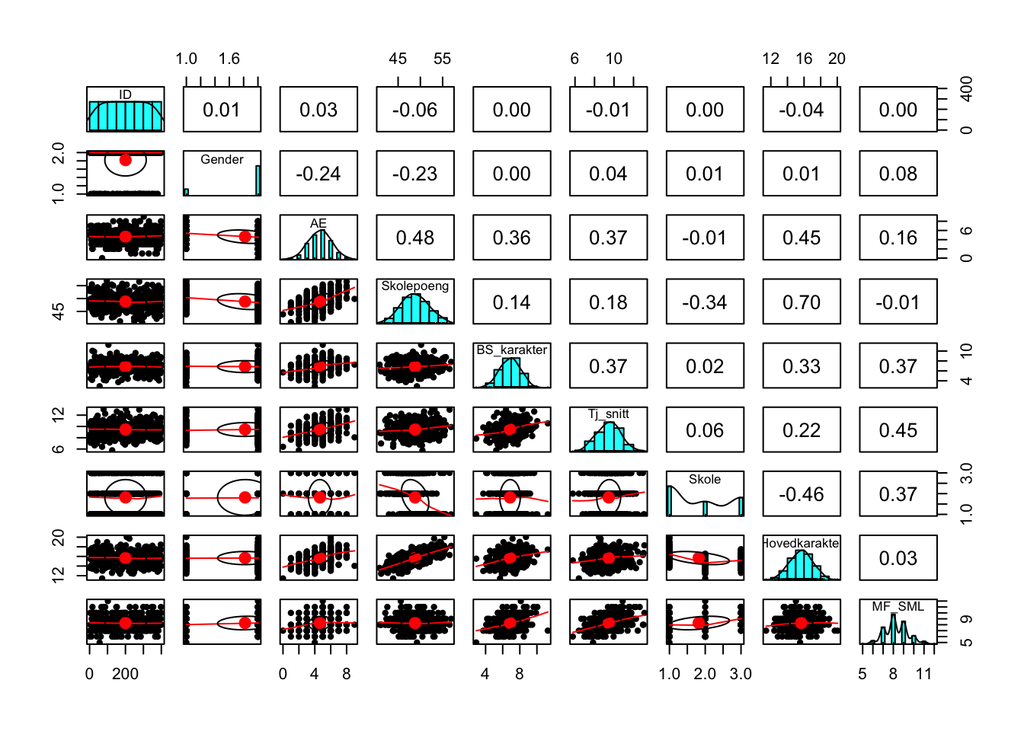

```r
pairs.panels(data)
```

Dette er alle variablene i data. Og som dere ser tar den ikke hensyn til om data er på nominal eller ordinal nivå. Men vi kan selvsagt subsette for å plukke ut de variablene vi ønsker å inkludere.

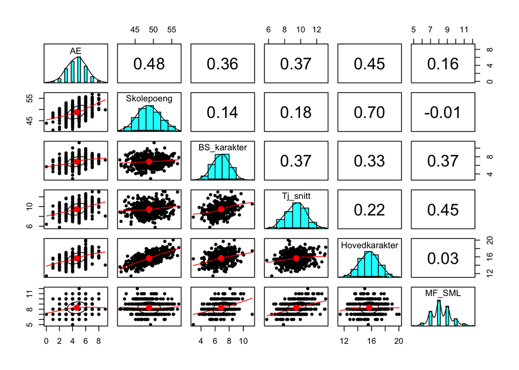

```r
pairs.panels(data[,-c(1, 2, 7)])
```

Nå bruker vi fremdeles bare defaultene for funksjonen. Vi kan sjekke hjelpfila for å se hvilke muligheter vi har:

```r
?pairs.panels
```

Og så bruker vi dette til å gjøre om innstillingene for plottet slik vi vil ha det. For eksempel:

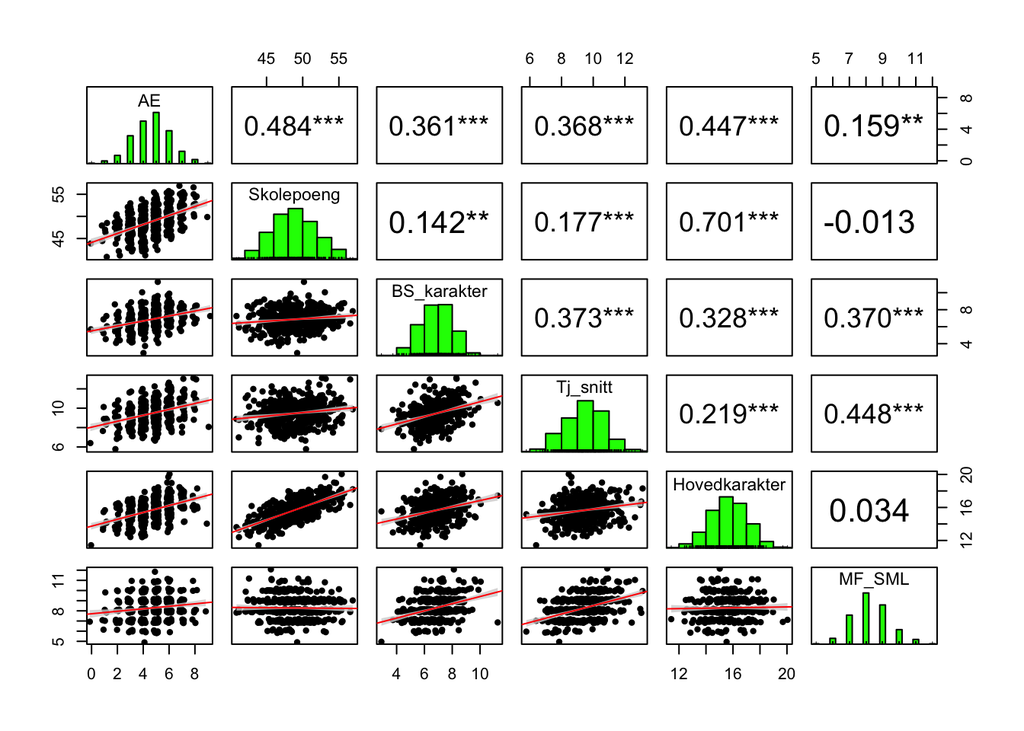

```r
pairs.panels(data[,-c(1, 2, 7)],
             method = "pearson",
             digits = 3,
             density = FALSE,
             lm = TRUE,
             ellipses = FALSE,
             jiggle = TRUE,
             factor = 1,
             hist.col = "green",
             stars = TRUE,
             ci = TRUE)
```

## Plotting

En annen måte å titte på dataene på er selvsagt å plotte dem. Til plotting skal vi bruke en pakke som heter `ggplot2`, som er et helt utrolig kraftig og fleksibelt verktøy. Dere kommer aldri mer til å ønske å inkludere et plott fra SPSS i en artikkel igjen, hvis dere fikser ggplot.

Funksjonen ggplot tar følgende argumenter: Vi starter med å angi hvilket datasett vi bruker. Som neste argument bruker vi `aes()`-funksjonen (for aesthetics) til å angi hvilken variabel vi ønsker på hvilken akse. Til slutt velger vi et geom, som bestemmer utseendet på plottet:

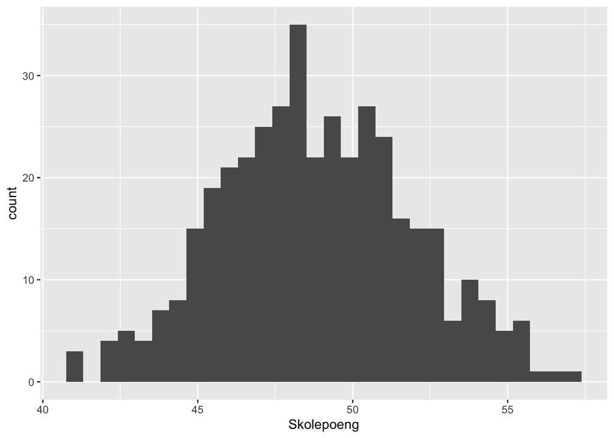

```r
plot1 <- ggplot(data, aes(x = Skolepoeng)) +
        geom_histogram()
plot1
```

Hvis vi ikke hadde brukt histogram, men et annen geom, så hadde vi fått et annet plot:

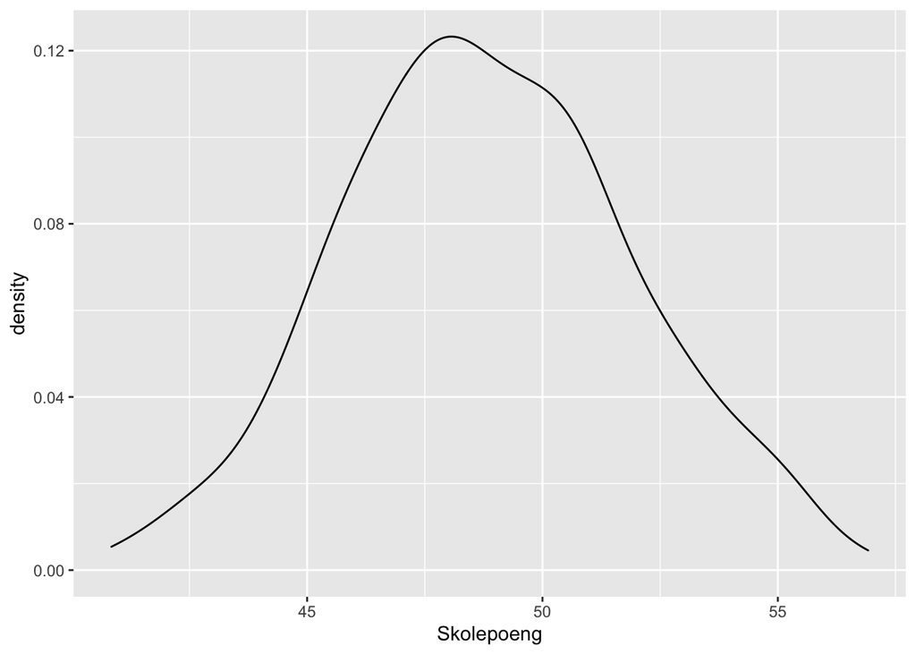

```r
plot2 <- ggplot(data, aes(x = Skolepoeng)) +
        geom_density()
plot2
```

Så kommer et triks. Vi bruker `aes()` til å mappe variabler til akser, ikke sant? Vi kan bruke `aes()` ikke bare til å mappe variabler til akser, men til andre attributter ved plottet også, som farge:

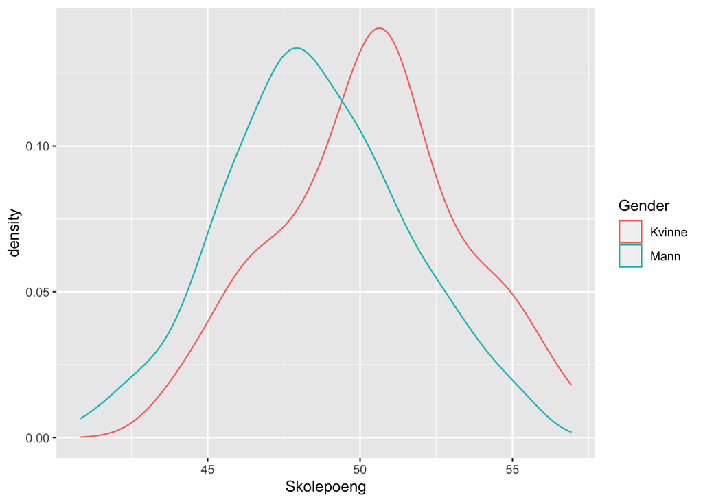

```r
plot3 <- ggplot(data, aes(x = Skolepoeng, colour = Gender)) +
        geom_density()
plot3
```

Eller:

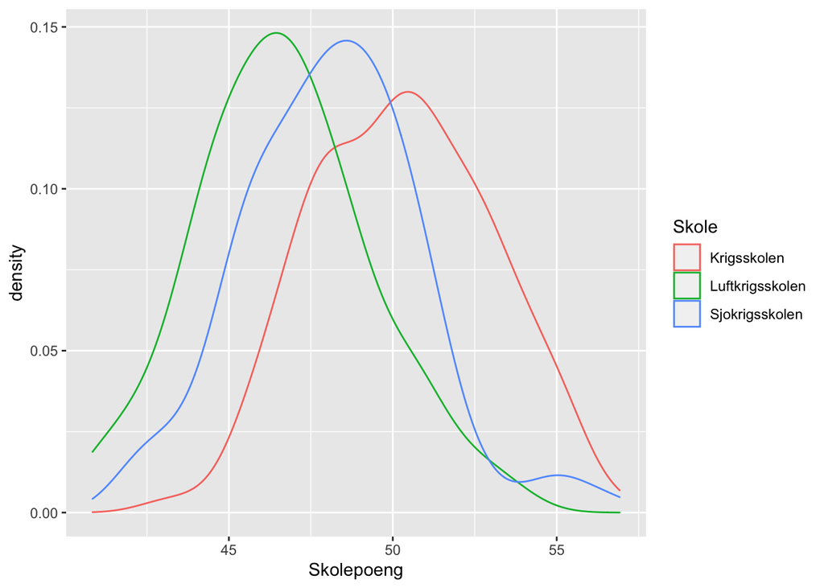

```r
plot4 <- ggplot(data, aes(x = Skolepoeng, colour = Skole)) +
        geom_density()
plot4
```

Til nå ser dere at jeg bare har brukt default innstillinger på geomene. Jeg har ikke gitt dem noen argumenter overhodet. Men det er nær sagt uendelig med muligheter. Som et enkelt eksempel kan jeg bytte colour med fill, og velge hvor gjennomsiktig fyllet skal være:

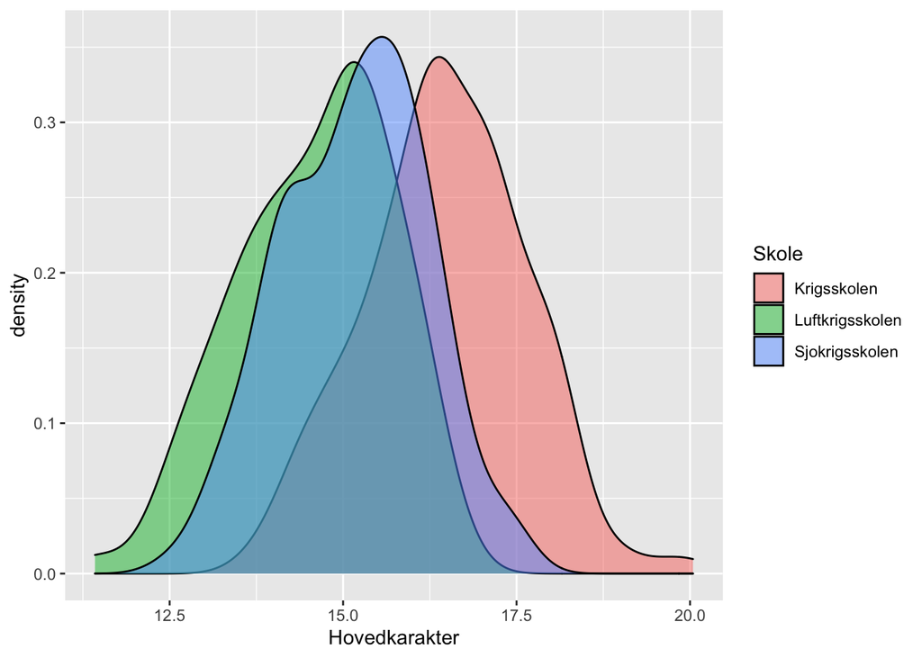

```r
plot5 <- ggplot(data, aes(x = Hovedkarakter, fill = Skole)) +
        geom_density(alpha = .5)
plot5
```

Det finnes geomer for virkelig alt mulig. F.eks boxplot:

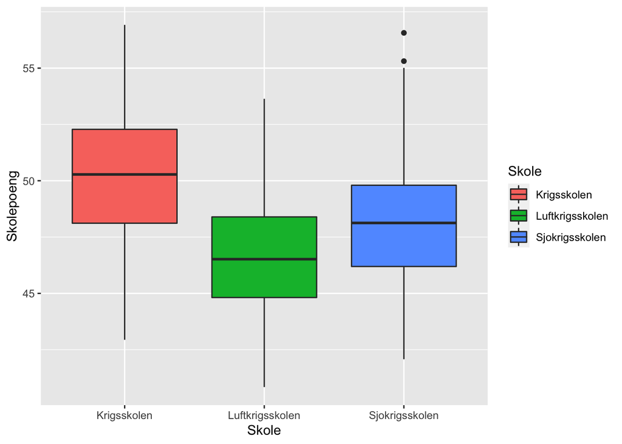

```r
plot6 <- ggplot(data, aes(x = Skole, y = Skolepoeng, fill = Skole)) +
        geom_boxplot()
plot6
```

Og vi kan ta i bruk y-aksen og mappe en variabel til den også, f.eks med point-geomet:

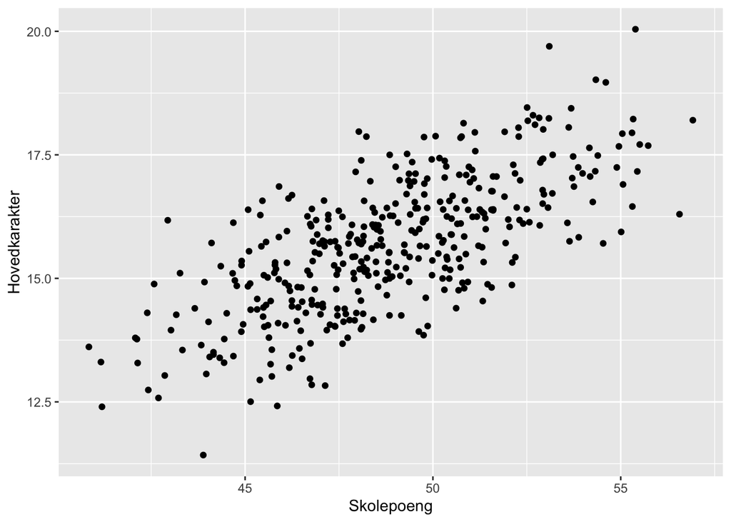

```r
plot7 <- ggplot(data, aes(x = Skolepoeng, y = Hovedkarakter)) +
        geom_point()
plot7
```

Vi kan kombinere flere geoms, for å bygge plottet vårt lag på lag. F.eks kan vi kombinere `geom_point()` med `geom_smooth()`, som gir oss forskjellige former for best fit-linje. Vi kan starte med med lineær regresjonslinje.

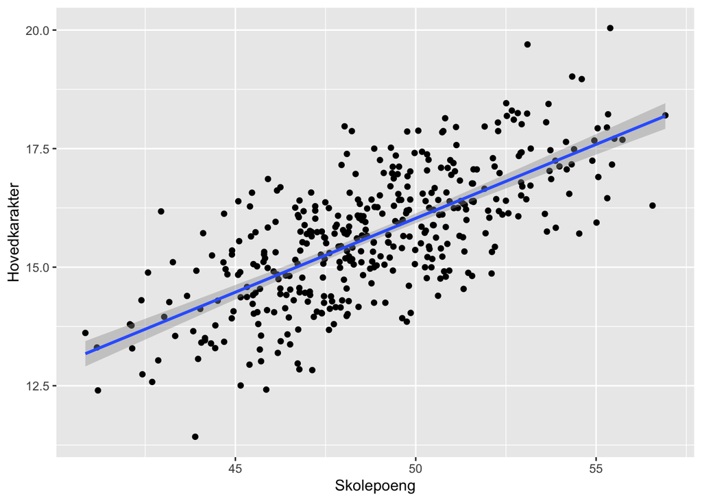

```r
plot8 <- ggplot(data, aes(x = Skolepoeng, y = Hovedkarakter)) +
        geom_point() +
        geom_smooth(method = "lm")
plot8
```

Det finnes mange andre også. Bare sjekk mulige argumenter i hjelp-fila til `geom_smooth()`, hvilke muligheter under method du har. F.eks en loess-linje:

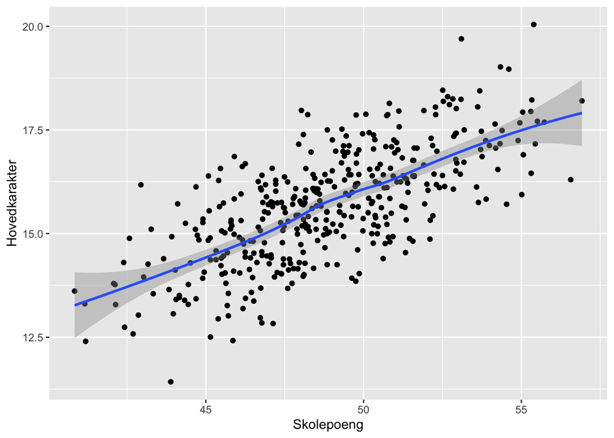

```r
plot9 <- ggplot(data, aes(x = Skolepoeng, y = Hovedkarakter)) +
        geom_point() +
        geom_smooth(method = "loess")
plot9
```

Men la oss beholde den lineære, men heller mappe en variabel til farge igjen:

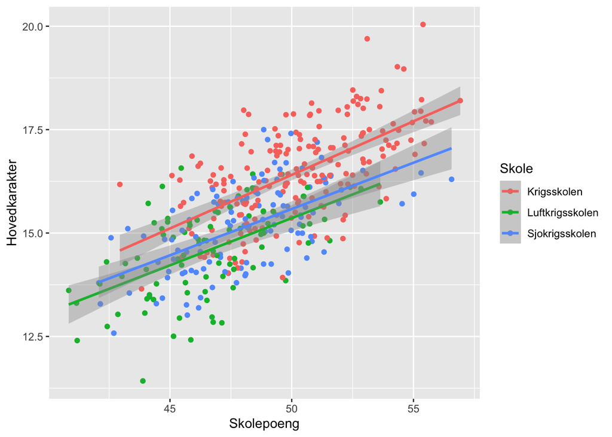

```r
plot10 <- ggplot(data, aes(x = Skolepoeng, y = Hovedkarakter, colour = Skole)) +
        geom_point() +
        geom_smooth(method = "lm")
plot10
```

Dette var ment som en smakebit på ggplot. Og jeg har knapt touchet innpå mulighetene til å definere absolutt alt på disse plottene. Egne farger, konfidensintervall av eller på, hvor stort, definere labels, tittel, tykkelser på linjer etc. etc. Her er det bare å utforske hjelp-filene, eller google etter det du lurer på. Det finnes et tonn av ulike tutorials på hvordan man gjør alt mulig med ggplot, det er bare å søke dem opp.

Det finnes også en del pakker som bygger videre på ggplot. De tar enkle argumenter og gir dem videre til ggplot for å lage en del spesialplot, som f.eks, interaksjonsplot eller Johnson-Neyman plot. Sjekk ut pakkene `ggstatsplot`, f.eks., eller `interactions`.

## Pipes

Ok, her kommer et bra triks for å holde koden ryddig og lesbar.

*keynote*

Ok, så la oss demoe piper. Vi bruker datasettet med flydata igjen.

La oss si at vi er interessert i flyvninger fra NYs JFK, til Los Angeles. Og vi er interessert i hvorvidt det er forskjeller i forsinkelser på tvers av f.eks. vår og høst. Og vi vil se resultater for ulike flyselskapene.

```r
flights %>%
        filter(origin == "JFK" & dest == "LAX") %>%
        filter(month == 3:5 | month == 9:11) %>%
        select(origin, dest, arr_delay, carrier, month) %>%
        mutate(season = ifelse(month < 6, "spring", "fall")) %>%
        group_by(season, carrier) %>%
        summarise(delay = mean(arr_delay, na.rm =TRUE)) %>% #kjør koden
        pivot_wider(names_from = season, values_from = delay)
```

```
## # A tibble: 5 × 3
##   carrier   fall spring
##   <chr>    <dbl>  <dbl>
## 1 AA      -4.66  -6.81
## 2 B6      -4.98  -9.84
## 3 DL      -7.32  -7.60
## 4 UA      -4.78   0.591
## 5 VX       0.897  2.73
```

Og hvis vi vil assigne dette til et objekt kan vi gjøre det helt øverst, til venstre.

Jeg skal ikke demonstrere ytterligere hvordan denne koden hadde sett ut uten bruk av pipes. Jeg tipper dere ser selv at det hadde vært ganske mye mer rotete.

# RMarkdown

Hvor mange har hørt om Markdown?

Markdown er genialt. Det er en slags syntax som er utviklet for å brukes i ren-tekst-filer, for å formatere tekt med overskrifter, bullets etc. I RStudio kan vi kombinere dette med R i et RMarkdown-dokument. Dette har noen helt fantastiske fordeler, men istedet for at jeg ramser opp de nå tror jeg vi bare skal prøve, og så ser dere. Så kan vi snakke om noen bruksområder etterpå.

Da kan dere starte med å åpne en ny fil, og velge type RMarkdown.

Gi den en tittel, og velg type HTML, i første omgang.

Når den er åpen så kan dere lagre den, og gi den et filnavn.

Markdown er et system for å formattere tekst på tvers av alle plattformer. Hensikten er at teksten skal være lett lesbar om du åpner den i en ren teksteditor, men også hvis den renderes skikkelig. Jeg skal vise noen eksempler.

# Dette er en nivå 1 overskrift

## Og dette er en nivå 2 overskrift.

Og slik kan du holde på til nivå 6. Vi kan også si at tekst skal være i *kursiv* eller stå med **fete typer**.

Vi kan også lage punktlister:

- med ett punkt
- to punkter
- og enda flere punkter
  - og vi kan ha underpunkter
  - og enda flere underpunkter på lista
- før vi fortsetter med vanlige punkter igjen

Lister kan også være nummererte:

1. slik som dette
2. dette
3. og dette

Vi kan til og med lage tabeller:

| Kolonneoverskrift | Enda en kolonneoverskrift | Den siste kolonnen |
| --- | --- | --- |
| Egg | Jordbærsyltetøy | Kjøttboller |
| Melk | Blåbærsyltetøy | Kjøttkaker |
| Mel | Brunost | Kjøttdeig |

Og så kommer jo virkelig magien. Vi kan kombinere vanlig tekst, ment for lesing, med R-kode i et dynamisk dokument.

```r
#Dette er en kodechunk. Som et eksempel kan vi copy/paste inn koden vi brukte tidligere, med flytidene.
```

I denne studien har vi undersøkt forskjeller i forsinkelser på fly som gikk på våren og fly som gikk på høsten. Vi har spesifikt undersøkt dette for alle fly fra New Yorks JFK til Los Angeles LAX i 2013.

Fordelt på flyselskaper så ankomstforsinkelsene slik ut (angitt i minutter. Negative tall angir at flyet ankom før rutetid):

| carrier | fall | spring |
| --- | --- | --- |
| AA | -4.66 | -6.81 |
| B6 | -4.98 | -9.84 |
| DL | -7.32 | -7.60 |
| UA | -4.78 | 0.59 |
| VX | 0.90 | 2.73 |

```r
varfly <- flights %>%
        filter(origin == "JFK" & dest == "LAX") %>%
        filter(month == 3:5)
hostfly <- flights %>%
        filter(origin == "JFK" & dest == "LAX") %>%
        filter(month == 9:11)
```

Utvalget vårt besto av samtlige 952 fly som fløy denne ruta i de tre vårmånedene mars, april og mai, samt samtlige 932 fly som fløy denne ruta i de tre høstmånedene september, oktober og november, totalt 1884 fly.

## lineære modeller / regresjoner

Til slutt hadde jeg tenkt å vise dere hvordan helt ordinære regresjoner virker i R. Dette er en intro til R, ikke til statisikk, men dette gir oss en mulighet til å teste regresjonssyntax for R, og den er normalt lik på tvers av pakker. Bl.a bruker de mest brukte multilevelpakkene til R, `lme4` og `brms`, en utvidet variant av samme syntax for å definere modeller:

Syntaxen er “avhengig variabel ~ uavhengig variabel + uavhengig variabel + …”

Så for funksjonen `lm()` blir modellen første argument og datasettet andre argument.

Outputen av funksjonen er et objekt, en såkalt “fitted model”, som inneholder all info. Men i kjent R-stil får du allikevel ikke noe info sånn uten videre. Den må du be om, ved å f.eks. kjøre `summary()`-funksjonen, med objektet som argument.

Hvis vi f.eks skal gjennomføre en hierarkisk multippel regresjon så kan vi bygge den første modellen, det første steget, på denne måten:

```r
model1 <- lm(Hovedkarakter ~ Skolepoeng + AE + Tj_snitt, data = data)
```

Og så, for å se hvordan dette gikk kan vi bruke enten `summary()`eller `tidy()`, som gir oss info i tibble-format. Dette er praktisk fordi vi da kan bruke denne tibblen videre, til å formatere tabeller i artikkelen eller lignende.

```r
#library(broom)
summary(model1)
```

```
##
## Call:
## lm(formula = Hovedkarakter ~ Skolepoeng + AE + Tj_snitt, data = data)
##
## Residuals:
##      Min       1Q   Median       3Q      Max
## -2.30226 -0.65510 -0.00289  0.62546  2.73972
##
## Coefficients:
##             Estimate Std. Error t value Pr(>|t|)
## (Intercept)  0.73882    0.87263   0.847  0.39770
## Skolepoeng   0.28145    0.01788  15.742  < 2e-16 ***
## AE           0.11036    0.03992   2.764  0.00597 **
## Tj_snitt     0.07090    0.04213   1.683  0.09322 .
## ---
## Signif. codes:  0 '***' 0.001 '**' 0.01 '*' 0.05 '.' 0.1 ' ' 1
##
## Residual standard error: 0.9607 on 396 degrees of freedom
## Multiple R-squared:  0.5102, Adjusted R-squared:  0.5064
## F-statistic: 137.5 on 3 and 396 DF,  p-value: < 2.2e-16
```

```r
glance(model1)
```

```
## # A tibble: 1 × 12
##   r.squared adj.r.squared sigma statistic  p.value    df logLik   AIC   BIC
##       <dbl>         <dbl> <dbl>     <dbl>    <dbl> <dbl>  <dbl> <dbl> <dbl>
## 1     0.510         0.506 0.961      137. 4.87e-61     3  -550. 1109. 1129.
## # … with 3 more variables: deviance <dbl>, df.residual <int>, nobs <int>
```

```r
tidy(model1)
```

```
## # A tibble: 4 × 5
##   term        estimate std.error statistic  p.value
##   <chr>          <dbl>     <dbl>     <dbl>    <dbl>
## 1 (Intercept)   0.739     0.873      0.847 3.98e- 1
## 2 Skolepoeng    0.281     0.0179    15.7   1.05e-43
## 3 AE            0.110     0.0399     2.76  5.97e- 3
## 4 Tj_snitt      0.0709    0.0421     1.68  9.32e- 2
```

Så kan vi lage en ny modell av neste steg i den hierarkiske regresjonen:

```r
model2 <- lm(Hovedkarakter ~ Skolepoeng + AE + Tj_snitt + BS_karakter, data = data)
summary(model2)
```

```
##
## Call:
## lm(formula = Hovedkarakter ~ Skolepoeng + AE + Tj_snitt + BS_karakter,
##     data = data)
##
## Residuals:
##      Min       1Q   Median       3Q      Max
## -2.45489 -0.64147  0.04957  0.60720  2.67185
##
## Coefficients:
##              Estimate Std. Error t value Pr(>|t|)
## (Intercept) -0.251303   0.858146  -0.293    0.770
## Skolepoeng   0.285567   0.017230  16.574  < 2e-16 ***
## AE           0.054062   0.039700   1.362    0.174
## Tj_snitt     0.004427   0.042225   0.105    0.917
## BS_karakter  0.244817   0.043169   5.671 2.74e-08 ***
## ---
## Signif. codes:  0 '***' 0.001 '**' 0.01 '*' 0.05 '.' 0.1 ' ' 1
##
## Residual standard error: 0.925 on 395 degrees of freedom
## Multiple R-squared:  0.547,  Adjusted R-squared:  0.5425
## F-statistic: 119.3 on 4 and 395 DF,  p-value: < 2.2e-16
```

Info om R-squared på begge modellene finner vi i summary.

```r
anova(model1, model2)
```

```
## Analysis of Variance Table
##
## Model 1: Hovedkarakter ~ Skolepoeng + AE + Tj_snitt
## Model 2: Hovedkarakter ~ Skolepoeng + AE + Tj_snitt + BS_karakter
##   Res.Df    RSS Df Sum of Sq      F    Pr(>F)
## 1    396 365.46
## 2    395 337.95  1    27.516 32.161 2.744e-08 ***
## ---
## Signif. codes:  0 '***' 0.001 '**' 0.01 '*' 0.05 '.' 0.1 ' ' 1
```

## Pakker det er verdt å nevne

MBESS - Har flere nyttige funksjoner, bl.a. for å beregne reliabilitet og for å beregne konfidensintervaller på effektstørrelser

https://www3.nd.edu/~kkelley/site/MBESS.html

Psych - Har vi allerede tittet litt på, med funksjonen pairs.panels(), men inneholder svært mange andre nyttige funksjoner også, bl.a. en hel haug med forskjellige reliabilitetsmål, og en rekke statistiske tester.

http://personality-project.org/r/psych/

Interactions. Lettbrukt verktøykasse for interaksjoner. Anbefales!

https://interactions.jacob-long.com/index.html

metafor - Har ikke brukt denne selv, men jeg har fått med meg at det er en av de mest brukte metaanalysepakkene til R

http://www.metafor-project.org/doku.php

lme4 - En av flere multilevelpakker til R, men kanskje den nyeste og beste.

https://github.com/lme4/lme4/

Lavaan - LAtent VAriable ANalysis

SEM-pakke for R

http://lavaan.ugent.be

Swirl - Lær deg R, i R. Denne er genial. Det blir litt som å spille et spill.

likert